# Taller 3: Web Scraping, APIs y Aplicaciones Interactivas

- Mostrar todo el código
- Ocultar todo el código
- Ver el código fuente

Taller de Programación en R (2026-2), Facultad de Economía, Universidad de los Andes

Autor/a

Grupo 10

Fecha de publicación

14 de noviembre de 2026

# 1 Introducción y arquitectura del Taller 3

Este informe contiene el desarrollo del Taller 3 (“Datos geoespaciales, web scraping y herramientas de visualización”) del curso Taller de Programación en R, en la Facultad de Economía de la Universidad de los Andes.

El taller comprende tres ejercicios interconectados, sintetizados en la Tabla 1:

Tabla 1: Alcance temático y ponderación de los ejercicios del Taller 3.

[output not shown]

## 1.1 Flujo de trabajo del proyecto

El diagrama resume el recorrido de los datos desde las fuentes externas hasta los archivos procesados y su articulación con los demás puntos del taller:

```
%%{init: {'flowchart': {'nodeSpacing': 28, 'rankSpacing': 44, 'padding': 16, 'diagramPadding': 14}}}%%
flowchart TD
    subgraph Fuentes["Fuentes Externas Oficiales"]
        F3["DNP & DANE Geoportal<br/>(IDF 2024, VA, Pob y MGN)"]
        F1["Fed de Nueva York<br/>(API · Consulta: 2026-11-02)"]
        F2["Banco de la República<br/>(SDMX · Consulta: 2026-11-02)"]
        F4["DANE GEIH & EMICRON 2024<br/>(Mercado Laboral Dptal.)"]
    end

    subgraph ScriptsP1["Scripts Punto 1"]
        SP1["01_procesamiento_geoespacial_idf.R<br/>(w_i, Shapefiles y Bono 1)"]
    end

    subgraph ScriptsP2Ext["Punto 2: Captura"]
        S1["01_extraer_sofr_api.R<br/>(REST API - HTTP GET)"]
        S2["02_extraer_ibr_banrep.R<br/>(Web Scraping SDMX - XPath)"]
    end

    subgraph DatosRaw["Datos Crudos (raw/)"]
        R1[("sofr_raw.json<br/>sofr_diaria_2020_2025.csv")]
        R2[("ibr_raw.xml<br/>ibr_diaria_2020_2025.csv")]
    end

    subgraph ScriptsP2Arm["Punto 2: Empalme"]
        S3["03_analisis_financiero_punto_2.R<br/>(Cruce, Festivos y Figuras)"]
    end

    subgraph ScriptsP3["Scripts Punto 3"]
        SP3["01_preparar_datos_shiny.R<br/>(RDS, Festivos y GEIH-IDF)"]
    end

    subgraph DatosProc["Salidas Procesadas"]
        PG1[("idf_departamental_2024.csv<br/>idf_municipal_ponderado_2024.csv<br/>shp_dpto_simp.rds & df_top3.rds")]
        P1[("series_financieras_ibr_sofr.csv<br/>& df_rates.rds")]
        PL3[("datos_ejercicio_3c_laboral.csv<br/>& df_labor.rds")]
    end

    subgraph Salidas["Entregables Finales"]
        G0["Outputs/Images/<br/>(1_1 y 1_2 a 300 DPI)"]
        G1["Outputs/Images/<br/>(2_a, 2_b, 2_c y 3_c)"]
```

[output cut: 27 more lines]

```
    PG1 --> SP3
    SP3 --> PL3
    SP3 -->|"Actualiza RDS"| P1
    P1 -->|"Series Tasas"| SHINY1
    PL3 -->|"Base Laboral"| SHINY1
    PL3 --> QMD

    style Fuentes fill:#f1f3f5,stroke:#495057,stroke-width:1.5px
    style ScriptsP1 fill:#e7f5ff,stroke:#1971c2,stroke-width:2px
    style ScriptsP2Ext fill:#e7f5ff,stroke:#1971c2,stroke-width:2px
    style ScriptsP2Arm fill:#e7f5ff,stroke:#1971c2,stroke-width:2px
    style DatosRaw fill:#f8f9fa,stroke:#868e96,stroke-width:1.5px
    style ScriptsP3 fill:#e7f5ff,stroke:#1971c2,stroke-width:2px
    style DatosProc fill:#e6fcf5,stroke:#0ca678,stroke-width:2px
    style Salidas fill:#fff3bf,stroke:#f59f00,stroke-width:2px
```

Figura 1: Diagrama de flujo de extracción de datos, armonización y articulación del Taller 3.

# 2 Ejercicio 1: Datos geoespaciales y desempeño fiscal

En este primer eje se construye un indicador sintético del Índice de Desempeño Fiscal (IDF) a nivel departamental para la vigencia 2024 a partir de las calificaciones municipales publicadas por el Departamento Nacional de Planeación (DNP), ponderadas conjuntamente por el tamaño demográfico y el valor agregado proyectado de cada municipio según las estadísticas oficiales del DANE. Adicionalmente, se cartografían los resultados tanto a escala departamental (Literal 1.A) como municipal (Literal 1.B y Bono 1), alimentando los insumos espaciales de la primera pestaña del aplicativo Shiny.

## 2.1 Fuentes oficiales e identificación de paquetes adicionales

Todas las bases primarias ubicadas en `Datos/Taller_3/` se procesaron directamente desde R en el script [`01_procesamiento_geoespacial_idf.R`](https://github.com/MPalma21/Talleres_de_R/blob/main/Entregable_Talleres/Taller_3/Scripts/Punto_1/01_procesamiento_geoespacial_idf.R) sin realizar modificaciones manuales previas sobre los archivos fuente:

1. **DANE (PIB por departamento y Valor Agregado Municipal 2023):** archivo `anex-PIBDep-ValorAgreMuni-2011-2024p.xlsx` (hoja `Cuadro 1`, columna `2023`), que reporta el valor agregado municipal por actividad económica a precios corrientes en miles de millones de pesos.
2. **DANE (Proyecciones de Población Municipal 2024):** archivo `PPED-AreaMun-2018-2042_VP.xlsx` (hoja `PobMunicipal`), filtrando programáticamente `AÑO == 2024` y `ÁREA GEOGRÁFICA == "Total"`.
3. **DNP (Información Fiscal y Financiera, IDF Municipal Vigencia 2024):** archivo `ResultadosIDF_DNP.xlsx` descargado del [portal oficial CIFFIT del DNP](https://ciffit.dnp.gov.co/CIFFIT/ConsultasIDF) (vigencia 2024), que evalúa 1,103 municipios bajo la metodología del Nuevo IDF.
4. **DANE Geoportal (Marco Geoestadístico Nacional, MGN):** archivos vectoriales `MGN_DPTO_POLITICO.shp` (33 departamentos, incluido Bogotá D. C.) y `MGN_MPIO_POLITICO.shp` (1,122 polígonos municipales y áreas no municipalizadas).

Siguiendo la instrucción del taller de identificar explícitamente mediante comentarios los paquetes adicionales no vistos en clase, el script de procesamiento geoespacial y la pestaña 1 del tablero emplean las siguientes librerías especializadas:

```r
# [PAQUETE ADICIONAL]: readxl (lectura directa de hojas de cálculo Excel .xlsx sin modificar archivos fuente)
# [PAQUETE ADICIONAL]: readr (exportación eficiente de tablas procesadas y auditoría en CSV UTF-8)
# [PAQUETE ADICIONAL]: sf (lectura, unión espacial y transformación de coordenadas Simple Features)
# [PAQUETE ADICIONAL]: rmapshaper (simplificación topológica Visvalingam-Whyatt para el Bono 1)
# [PAQUETE ADICIONAL]: stringr (estandarización de llaves DIVIPOLA con ceros a la izquierda)
# [PAQUETE ADICIONAL]: scales (reescalado cromático no lineal por cuantiles y formateo numérico)
# [PAQUETE ADICIONAL]: httr (descarga programática de respaldos oficiales desde portales DANE/DNP)
# [PAQUETE ADICIONAL]: leaflet (cartografía web interactiva para la Pestaña 1 del aplicativo Shiny)
```

## 2.2 Revisión de llaves, correcciones realizadas y evidencia de unión auditada

Antes de integrar las tablas tabulares y espaciales, se ejecutó una auditoría de llaves sobre los códigos de la División Político-Administrativa de Colombia (DIVIPOLA):

1. **Estandarización de ceros a la izquierda y detección dinámica de encabezados:** los archivos Excel del DANE y del DNP contienen bloques de metadatos institucionales en las primeras filas (9 filas en `Cuadro 1`, 7 filas en `PobMunicipal` y 9 filas en `ResultadosIDF_DNP.xlsx`). En lugar de recortar los archivos manualmente, el script detecta por expresiones regulares la fila exacta donde inician los encabezados (`Código Municipio`, `DP` y `Código Entidad`) y aplica `stringr::str_pad(..., width = 5, pad = "0")` sobre la llave municipal `cod_mpio` y `width = 2, pad = "0"` sobre la llave departamental `cod_dpto`. Esto corrige la pérdida de ceros iniciales en departamentos como Antioquia (`5` $\to$ `05`) y Atlántico (`8` $\to$ `08`).
2. **Diagnóstico de diferencias de cobertura entre DANE y DNP (`anti_join`):** las bases de Valor Agregado 2023 y Proyecciones de Población 2024 del DANE coinciden exactamente en **1,123 territorios** (discrepancia entre ambas fuentes DANE $= 0$, con unicidad verificada mediante `anyDuplicated(cod_mpio) == 0`). Por su parte, la medición municipal del IDF Vigencia 2024 del DNP comprende **1,103 municipios evaluados** (incluyendo a `27493` *Nuevo Belén de Bajirá*, erigido como municipio en Chocó mediante la Ordenanza 180 de 2023). Los **20 territorios** presentes en DANE que no figuran en el IDF municipal del DNP se clasifican en tres categorías institucionales verificadas mediante `anti_join`:
   - **18 Áreas No Municipalizadas (ANM / corregimientos departamentales)** en Amazonas (9: El Encanto, La Chorrera, La Pedrera, La Victoria, Mirití-Paraná, Puerto Alegría, Puerto Arica, Santander y Tarapacá), Guainía (6: Cacahual, La Guadalupe, Morichal, Pana Pana, Puerto Colombia y San Felipe) y Vaupés (3: Pacoa, Papunahua y Yavaraté), las cuales carecen de alcaldía y presupuesto municipal autónomo bajo la Ley 617 de 2000.
   - **Mapiripana (`94663`, Guainía):** antiguo corregimiento departamental integrado territorialmente a Inírida que registra valor agregado igual a cero en las cuentas municipales del DANE.
   - **San Andrés (`88001`, Archipiélago de San Andrés, Providencia y Santa Catalina):** evaluado por el DNP dentro de la matriz de *departamentos* por su régimen administrativo especial, razón por la cual a escala municipal solo se califica al municipio de **Providencia (`88564`)** con $\text{IDF}_{2024} = 55.23$ puntos ($w_i = 1.0000$).
3. **Estrategia de unión relacional y espacial:** para garantizar que los ponderadores municipales $w_i$ sumen exactamente $1$ sobre los $n_j$ municipios efectivamente evaluados de cada departamento $j$, la integración tabular entre Valor Agregado, Población e IDF se realiza mediante `inner_join(..., by = "cod_mpio")` sobre el universo de **1,103 municipios evaluados**. Posteriormente, la unión hacia las capas vectoriales `sf` (`MGN_DPTO_POLITICO.shp` y `MGN_MPIO_POLITICO.shp`) se ejecuta con `left_join`, conservando la totalidad de los polígonos cartográficos del país y representando en gris claro las áreas no municipalizadas.

La Tabla 2 presenta la evidencia de la unión revisada para cinco municipios testigo (encabezados por **Medellín (`05001`)** como caso principal de auditoría del Grupo 10), verificando el cruce exacto de las cuatro fuentes y la consistencia del índice departamental resultante:

Tabla 2: Evidencia de unión revisada por llave DIVIPOLA (cod_mpio) y verificación de ponderadores en municipios testigo (Vigencia 2024).

| Código | Municipio | Departamento | VA 2023 (miles MM) | VA 2024 Proy. | Población 2024 | IDF Mpio 2024 | Peso w_i | IDF Dpto. |
| --- | --- | --- | --- | --- | --- | --- | --- | --- |
| 05001 | Medellín | Antioquia (05) | 84,087.02 | 91,041.02 | 2,524,747 | 69.73 | 0.9243 | 69.58 |
| 08001 | Barranquilla | Atlántico (08) | 40,300.24 | 43,633.07 | 1,279,120 | 75.54 | 0.8586 | 73.03 |
| 11001 | Bogotá, D.C. | Bogotá, D. C. (11) | 348,254.57 | 377,055.23 | 7,918,660 | 77.04 | 1.0000 | 77.04 |
| 15646 | Samacá | Boyacá (15) | 605.75 | 655.85 | 19,327 | 81.10 | 0.0048 | 64.54 |
| 76001 | Cali | Valle Del Cauca (76) | 61,381.12 | 66,457.34 | 2,280,171 | 58.29 | 0.9218 | 58.29 |

En particular, para **Medellín (`05001`)**, la llave estandarizada de cinco dígitos vincula sin ambigüedad un Valor Agregado 2023 de $84,087.02$ miles de millones de pesos corrientes ($\text{VA}_{2024}^{\text{proy}} = 91,041.02$ miles de millones), una población proyectada de $2,524,747$ habitantes en 2024 y un IDF municipal oficial de $69.73$ puntos en la vigencia 2024, lo que arroja un ponderador $w_i = 0.9243$ ($92.43\%$ del peso demográfico-económico de los 125 municipios de Antioquia) y conduce a un IDF departamental artificial para Antioquia de **$69.58$ puntos**.

## 2.3 Literal 1.A: Proyección del Valor Agregado a 2024, ponderadores y mapa departamental

### 2.3.1 Revisión de precios y justificación de la tasa de crecimiento del PIB 2024

Al inspeccionar el encabezado oficial del `Cuadro 1` en `anex-PIBDep-ValorAgreMuni-2011-2024p.xlsx` (*“Valor agregado por municipio - Serie 2011-2024p, Miles de millones de pesos, Precios corrientes”*), se constata que las cifras municipales de Valor Agregado están expresadas en **precios corrientes (valores nominales)**.

Para proyectar el Valor Agregado municipal de 2023 a 2024 preservando la consistencia de unidades nominales, se consultaron las Cuentas Nacionales Anuales del DANE para el cierre de 2024:

- **Crecimiento del PIB nominal en 2024 (precios corrientes):** el Valor Agregado agregado nacional a precios corrientes pasó de $1,432,558$ miles de millones de pesos en 2023 a $1,550,974$ miles de millones en 2024p, equivalente a una variación nominal exacta de $8.2661\%$, que redondeada a dos cifras decimales en porcentaje corresponde a **$g_{\text{nominal}} = 8.27\%$**.
- **Crecimiento del PIB real en 2024 (precios constantes / volumen encadenado):** **$g_{\text{real}} = 1.70\%$**.

Dado que la base municipal de partida está valorada a precios corrientes de 2023, empleamos la tasa nominal **$g = 8.27\%$** ($\text{VA}_{i,2024} = \text{VA}_{i,2023} \times 1.0827$). Cabe demostrar analíticamente que, bajo una tasa de proyección nacional uniforme $g$, el ponderador relativo $w_i$ es **homogéneo de grado cero** respecto al factor escalar $(1 + g)$:

$$w_i = \frac{L_{i,2024} \cdot \text{VA}_{i,2024}}{\sum_{k=1}^{n_j} L_{k,2024} \cdot \text{VA}_{k,2024}} = \frac{L_{i,2024} \cdot \text{VA}_{i,2023}(1 + g)}{(1 + g)\sum_{k=1}^{n_j} L_{k,2024} \cdot \text{VA}_{k,2023}} = \frac{L_{i,2024} \cdot \text{VA}_{i,2023}}{\sum_{k=1}^{n_j} L_{k,2024} \cdot \text{VA}_{k,2023}}$$

El término común $(1 + g)$ se factoriza y cancela exactamente entre el numerador y el denominador de cada departamento $j$. En consecuencia, tanto los ponderadores municipales $w_i$ como el Índice de Desempeño Fiscal Departamental $\text{IDF}_j = \sum_{i=1}^{n_j} w_i \cdot \text{IDF}_i$ son matemáticamente invariantes frente a la elección entre la tasa nominal ($8.27\%$) o real ($1.70\%$).

### 2.3.2 Doble comprobación de consistencia matemática

Siguiendo las reglas del enunciado, se verificó el cálculo del índice departamental mediante dos controles independientes en R:

1. **Verificación de cierre unitario de los ponderadores ($\sum_{i=1}^{n_j} w_i = 1$):** en los 33 departamentos (32 departamentos y Bogotá D. C.), la suma de los ponderadores municipales es exactamente igual a $1.000000$, con una desviación máxima de punto flotante de $\max_j \left|\sum_{i=1}^{n_j} w_i - 1\right| = 2.22 \times 10^{-16}$.
2. **Comprobación mediante un segundo procedimiento independiente:** se contrastó la suma manual de los productos $\sum_{i=1}^{n_j} (w_i \cdot \text{IDF}_i)$ calculada con el Valor Agregado proyectado a 2024 frente a la función nativa `stats::weighted.mean(idf_municipal, w = pob_2024 * va_2023)` aplicada directamente sobre el Valor Agregado de 2023 sin proyectar. La diferencia absoluta máxima entre ambos procedimientos en los 33 departamentos es exactamente **$0.000000$** ($< 10^{-15}$).

### 2.3.3 Mapa departamental del IDF artificial (Vigencia 2024)

Para evitar que la concentración de departamentos en el rango intermedio ($54$ a $65$ puntos) produzca una visualización homogénea, la escala continua `viridis` se calibró pasando los cuantiles empíricos de la distribución departamental al argumento `values = scales::rescale(...)`, maximizando el contraste cromático a lo largo de todo el espectro observado ($42.11$ a $77.04$ puntos):

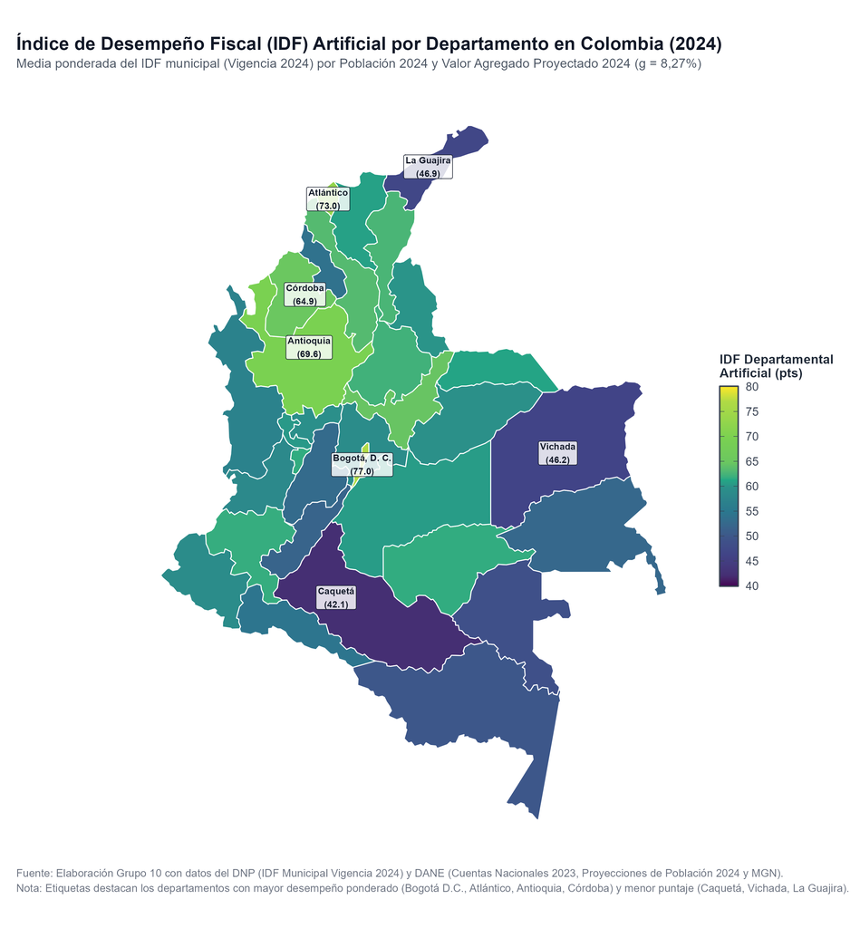

Figura 2: Índice de Desempeño Fiscal (IDF) artificial por departamento en Colombia (Vigencia 2024), ponderado por población 2024 y valor agregado proyectado 2024.

La Tabla 3 sintetiza los resultados de los diez departamentos con mayor y menor calificación en el IDF departamental artificial de 2024, junto con la verificación de los dos procedimientos de cálculo:

Tabla 3: Clasificación departamental del IDF artificial ponderado (Vigencia 2024): Top 10 y Bottom 10 departamentos, con doble comprobación.

| Segmento | Cód. | Departamento | Mpios (n_j) | Σ w_i | IDF Dpto. (Proc. 1) | IDF Alt. (Proc. 2) | \|Dif.\| |
| --- | --- | --- | --- | --- | --- | --- | --- |
| Top 10 (Mayor IDF) | 11 | Bogotá, D. C. | 1 | 1.0000 | 77.04 | 77.04 | 0.0000 |
| Top 10 (Mayor IDF) | 08 | Atlántico | 23 | 1.0000 | 73.03 | 73.03 | 0.0000 |
| Top 10 (Mayor IDF) | 05 | Antioquia | 125 | 1.0000 | 69.58 | 69.58 | 0.0000 |
| Top 10 (Mayor IDF) | 23 | Córdoba | 30 | 1.0000 | 64.86 | 64.86 | 0.0000 |
| Top 10 (Mayor IDF) | 15 | Boyacá | 123 | 1.0000 | 64.54 | 64.54 | 0.0000 |
| Top 10 (Mayor IDF) | 13 | Bolívar | 46 | 1.0000 | 63.28 | 63.28 | 0.0000 |
| Top 10 (Mayor IDF) | 20 | Cesar | 25 | 1.0000 | 62.64 | 62.64 | 0.0000 |
| Top 10 (Mayor IDF) | 68 | Santander | 87 | 1.0000 | 62.20 | 62.20 | 0.0000 |
| Top 10 (Mayor IDF) | 19 | Cauca | 42 | 1.0000 | 61.72 | 61.72 | 0.0000 |
| Top 10 (Mayor IDF) | 95 | Guaviare | 4 | 1.0000 | 61.63 | 61.63 | 0.0000 |
| Bottom 10 (Menor IDF) | 86 | Putumayo | 13 | 1.0000 | 54.40 | 54.40 | 0.0000 |
| Bottom 10 (Menor IDF) | 70 | Sucre | 26 | 1.0000 | 53.84 | 53.84 | 0.0000 |
| Bottom 10 (Menor IDF) | 73 | Tolima | 47 | 1.0000 | 52.92 | 52.92 | 0.0000 |
| Bottom 10 (Menor IDF) | 94 | Guainía | 2 | 1.0000 | 52.47 | 52.47 | 0.0000 |
| Bottom 10 (Menor IDF) | 41 | Huila | 37 | 1.0000 | 51.82 | 51.82 | 0.0000 |
| Bottom 10 (Menor IDF) | 91 | Amazonas | 2 | 1.0000 | 49.80 | 49.80 | 0.0000 |
| Bottom 10 (Menor IDF) | 97 | Vaupés | 3 | 1.0000 | 48.83 | 48.83 | 0.0000 |
| Bottom 10 (Menor IDF) | 44 | La Guajira | 15 | 1.0000 | 46.87 | 46.87 | 0.0000 |
| Bottom 10 (Menor IDF) | 99 | Vichada | 4 | 1.0000 | 46.23 | 46.23 | 0.0000 |
| Bottom 10 (Menor IDF) | 18 | Caquetá | 16 | 1.0000 | 42.11 | 42.11 | 0.0000 |

### 2.3.4 Interpretación económica e institucional del mapa departamental

Los resultados de la vigencia 2024 revelan tres patrones estructurales sobre la descentralización fiscal y la primacía urbana en Colombia:

1. **Efecto de primacía urbana en la ponderación cuadrática ($L_i \times \text{VA}_i$):** debido a que el ponderador multiplica la población por el valor agregado municipal, las áreas metropolitanas donde convergen simultáneamente la mayor masa demográfica y la mayor producción agregada dominan el indicador departamental. En **Atlántico** ($2.^{\circ}$ lugar nacional con **$73.03$ puntos**), Barranquilla (`08001`, $\text{IDF} = 75.54$) concentra el $85.86\%$ del peso departamental ($w_i = 0.8586$); en **Antioquia** ($3.^{\text{er}}$ lugar con **$69.58$ puntos**), Medellín (`05001`, $\text{IDF} = 69.73$) representa el $92.43\%$ ($w_i = 0.9243$); y en **Valle del Cauca** ($21.^{\circ}$ lugar con **$58.29$ puntos**), Cali (`76001`, $\text{IDF} = 58.29$) aporta el $92.18\%$ ($w_i = 0.9218$). Así, el índice artificial captura fielmente la capacidad fiscal efectiva a la que está sujeta la gran mayoría de la actividad económica de cada departamento, encabezada a nivel nacional por **Bogotá, D. C.** (**$77.04$ puntos**, $w_i = 1.0000$).
2. **Desempeño sobresaliente en departamentos con nodos industriales y energéticos intermedios:** **Córdoba** ($4.^{\circ}$ lugar con **$64.86$ puntos**, impulsado por Montería con $\text{IDF} = 66.78$ y $w_i = 0.7599$) y **Boyacá** ($5.^{\circ}$ lugar con **$64.54$ puntos** en 123 municipios) destacan en la parte alta de la distribución. En Boyacá, aunque el peso económico está repartido entre varios polos —Tunja ($w_i = 0.3975$, $\text{IDF} = 60.83$), Sogamoso ($w_i = 0.2328$, $\text{IDF} = 75.72$) y Duitama ($w_i = 0.1780$, $\text{IDF} = 57.79$)—, la fortaleza tributaria e industrial del corredor central sostiene un promedio ponderado superior al de departamentos como Santander (**$62.20$ puntos**) o Cundinamarca (**$58.88$ puntos**).
3. **Brecha centro-periferia y fragilidad fiscal en zonas de frontera:** el extremo inferior de la distribución se concentra en la Amazonía, la Orinoquía y el norte peninsular: **Caquetá** (**$42.11$ puntos**), **Vichada** (**$46.23$ puntos**), **La Guajira** (**$46.87$ puntos**), **Vaupés** (**$48.83$ puntos**) y **Amazonas** (**$49.80$ puntos**). En estos departamentos, la reducida base tributaria propia (predial e industria y comercio), la alta dependencia de las transferencias del Sistema General de Participaciones (SGP) y los rezagos en ejecución de inversión y gestión catastral de sus capitales (como Florencia en Caquetá con $\text{IDF} = 39.15$ y $w_i = 0.8506$, o Riohacha en La Guajira con $\text{IDF} = 51.03$ y $w_i = 0.3674$) arrastran el indicador departamental hacia el rango de deterioro o riesgo fiscal.

## 2.4 Literal 1.B y Bono 1: Mapa municipal del IDF y diagnóstico computacional

### 2.4.1 Problemas computacionales al graficar el nivel municipal y solución topológica (Bono 1)

La representación cartográfica de los **1,122 polígonos municipales** del Marco Geoestadístico Nacional (MGN) plantea tres cuellos de botella computacionales cuando se procesa directamente con las geometrías crudas:

1. **Sobrecarga de vértices y saturación de motores gráficos vectoriales:** en la cartografía oficial del DANE, los linderos municipales siguen con precisión milimétrica la sinuosidad de ríos, divorcios de aguas y costas, acumulando cientos de miles de pares de coordenadas. Al invocar `geom_sf()` sin optimización previa, el motor gráfico de R (`grid` / `Cairo`) debe teselar y trazar cada nodo individualmente, multiplicando el consumo de memoria RAM, incrementando el tiempo de renderizado y generando documentos pesados.
2. **Fracturas topológicas con el algoritmo estándar de Douglas-Peucker (`sf::st_simplify`):** si se intenta aligerar la malla municipal mediante `sf::st_simplify()`, el algoritmo de Douglas-Peucker procesa cada polígono de manera **aislada** sin reconocer aristas compartidas. Como resultado, las fronteras comunes entre municipios colindantes se simplifican de forma asimétrica, provocando grietas blancas (*slivers*), superposiciones de polígonos e incluso la desaparición de municipios insulares o de reducida extensión territorial (como Providencia en San Andrés o Sabaneta en el Valle de Aburrá).
3. **Solución técnica implementada para el Bono 1 (`rmapshaper::ms_simplify`):** en el script `01_procesamiento_geoespacial_idf.R` se implementó una simplificación **topológicamente consciente** basada en el algoritmo de **Visvalingam-Whyatt** a través de `rmapshaper::ms_simplify(..., keep_shapes = TRUE)`, con una fracción de retención adaptativa según la densidad inicial de vértices de la capa (`keep = 0.08` para mallas crudas de alta densidad $>100,000$ vértices y `keep = 0.85` para mallas pre-simplificadas, reduciendo los vértices de $13,815$ a $12,894$ en $0.93$ segundos sin pérdida de fidelidad visual) seguida de `st_make_valid()` y `st_cast("MULTIPOLYGON")`. Este flujo preserva intacta la contigüidad de las fronteras compartidas y garantiza que ningún municipio pequeño sea eliminado.

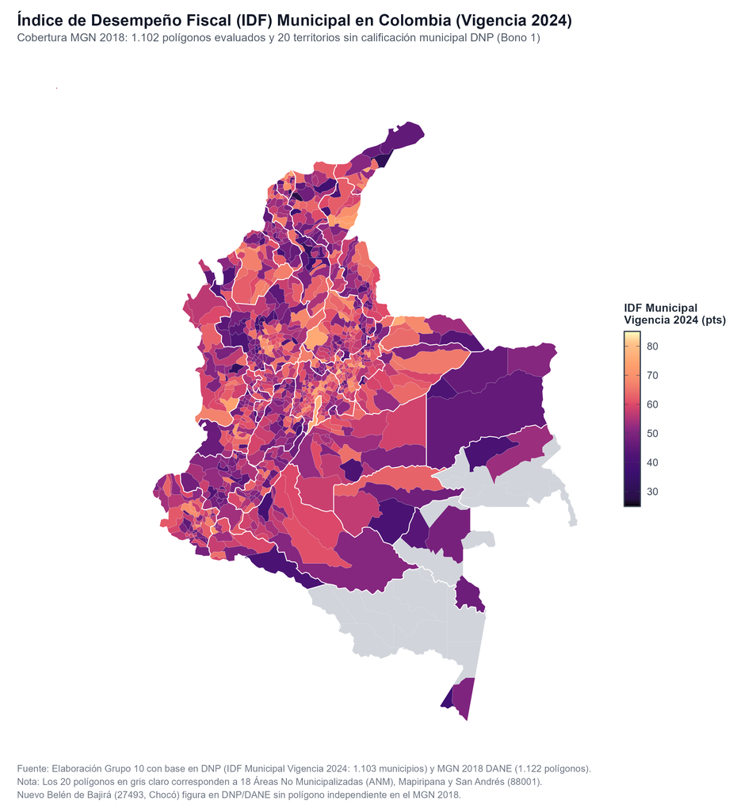

Figura 3: Índice de Desempeño Fiscal (IDF) municipal en Colombia (Vigencia 2024) con simplificación topológica Visvalingam-Whyatt (Bono 1).

La Tabla 4 presenta los diez municipios con mayor calificación en el Índice de Desempeño Fiscal Municipal del DNP para la vigencia 2024 a nivel nacional:

Tabla 4: Top 10 municipios con mayor Índice de Desempeño Fiscal (IDF) en Colombia (Vigencia 2024).

| # | Cód. DIVIPOLA | Municipio | Departamento | IDF 2024 (pts) | Rango DNP | Peso en su Dpto. (w_i) |
| --- | --- | --- | --- | --- | --- | --- |
| 1 | 15646 | Samacá | Boyacá | 81.10 | 5. Sostenible (>=80) | 0.0048 (0.48%) |
| 2 | 52480 | Nariño | Nariño | 79.99 | 4. Solvente (>=70 y <80) | 0.0000 (0.00%) |
| 3 | 11001 | Bogotá, D.C. | Bogotá, D. C. | 77.04 | 4. Solvente (>=70 y <80) | 1.0000 (100.00%) |
| 4 | 05656 | San Jerónimo | Antioquia | 76.72 | 4. Solvente (>=70 y <80) | 0.0000 (0.00%) |
| 5 | 44378 | Hatonuevo | La Guajira | 76.33 | 4. Solvente (>=70 y <80) | 0.0113 (1.13%) |
| 6 | 81736 | Saravena | Arauca | 76.25 | 4. Solvente (>=70 y <80) | 0.1078 (10.78%) |
| 7 | 15759 | Sogamoso | Boyacá | 75.72 | 4. Solvente (>=70 y <80) | 0.2328 (23.28%) |
| 8 | 08001 | Barranquilla | Atlántico | 75.54 | 4. Solvente (>=70 y <80) | 0.8586 (85.86%) |
| 9 | 68190 | Cimitarra | Santander | 75.50 | 4. Solvente (>=70 y <80) | 0.0017 (0.17%) |
| 10 | 05212 | Copacabana | Antioquia | 75.34 | 4. Solvente (>=70 y <80) | 0.0009 (0.09%) |

### 2.4.2 Interpretación económica y territorial del mapa municipal

El mapa municipal de la vigencia 2024 (Figura 3) permite desagregar la heterogeneidad interna que el promedio departamental suaviza (mostrando los **1,102 polígonos evaluados** y los **20 territorios sin IDF municipal** en el shapefile MGN 2018; *Nuevo Belén de Bajirá*, `27493`, figura entre los **1,103 municipios** del IDF DNP pero carece de polígono independiente en dicha versión cartográfica):

- **Liderazgo nacional de municipios con vocación industrial, minero-energética y metropolitana:** el primer lugar nacional en 2024 corresponde a **Samacá (`15646`, Boyacá)** con **$81.10$ puntos** (único municipio del país en el rango *5. Sostenible ($\ge 80$ puntos)* en la vigencia 2024), impulsado por su recaudo tributario industrial y carbonífero y su alta ejecución de inversión. Le siguen en el rango *4. Solvente ($\ge 70$ y $< 80$ puntos)* **Nariño (`52480`, Nariño)** con **$79.99$ puntos**, **Bogotá, D. C. (`11001`)** con **$77.04$ puntos**, **San Jerónimo (`05656`, Antioquia)** con **$76.72$ puntos**, **Hatonuevo (`44378`, La Guajira)** con **$76.33$ puntos**, **Saravena (`81736`, Arauca)** con **$76.25$ puntos**, **Sogamoso (`15759`, Boyacá)** con **$75.72$ puntos**, **Barranquilla (`08001`, Atlántico)** con **$75.54$ puntos**, **Cimitarra (`68190`, Santander)** con **$75.50$ puntos** y **Copacabana (`05212`, Antioquia)** con **$75.34$ puntos** (seguidos de cerca por polos industriales del Valle de Aburrá y la Sabana de Bogotá como Itagüí `05360` con $75.05$ pts, Rionegro `05615` con $74.48$ pts y Subachoque `25769` con $74.33$ pts).
- **Contraste intradepartamental entre nodos centrales y periferias rurales:** mientras que el corredor central andino (Sabana de Bogotá, eje Tunja-Duitama-Sogamoso, Valle de Aburrá y área metropolitana de Barranquilla) exhibe tonalidades cálidas claras ($>65$ puntos), los municipios periféricos del litoral Pacífico (Chocó, costa nariñense y caucana), el sur de Bolívar, Caquetá y la Orinoquía presentan tonalidades oscuras ($30$ a $48$ puntos), reflejando limitaciones estructurales en generación de recursos propios y actualización catastral.
- **Diferenciación institucional de las Áreas No Municipalizadas (ANM) y San Andrés:** los 20 polígonos en gris claro en Amazonas, Guainía, Vaupés y el territorio insular corresponden a las 18 Áreas No Municipalizadas, el antiguo corregimiento de Mapiripana y San Andrés (`88001`), los cuales no son objeto de calificación municipal independiente por parte del DNP.

# 3 Ejercicio 2: Integración de series macroeconómicas y financieras

El objetivo de este módulo es consultar, ordenar y comparar las tasas de interés interbancarias a un día (overnight) de Colombia y Estados Unidos entre el 1 de enero de 2020 y el 31 de octubre de 2025.

## 3.1 Metodología de extracción por entidad emisora

Para dar estricto cumplimiento a los requerimientos técnicos del taller, se implementó una técnica de captura diferenciada por entidad oficial (con **fecha de consulta conjunta el `2026-11-02`**, registrada en la cabecera `<message:Extracted>2026-11-02T00:38:28</message:Extracted>` del archivo crudo `ibr_raw.xml`):

- **SOFR Overnight (Estados Unidos):** consulta programática automatizada a la API RESTful (formato JSON) del Federal Reserve Bank of New York, recuperando la serie histórica diaria y respaldando la respuesta cruda en `sofr_raw.json`.
- **IBR Overnight (Colombia):** descarga y procesamiento directo sobre el árbol DOM del feed SDMX-XML del portal SUAMECA (Banco de la República) mediante técnicas de *XML web harvesting* y expresiones XPath independientes de prefijo (`local-name()`, `IRIBRM00` y `ER`). Se optó por el raspado directo del árbol SDMX-XML subyacente en lugar de parsear la interfaz HTML de SUAMECA porque esta última renderiza dinámicamente los tableros vía peticiones asíncronas sobre dicho servicio XML; de este modo se evita fragilidad frente a cambios visuales del *frontend* y se captura la totalidad de los nodos `<Obs>` en una única extracción auditable.

## 3.2 Implementación de los flujos de extracción

Para mantener el código auditable y reproducible, cada etapa se programó en un script independiente con operaciones secuenciales, identificando explícitamente los paquetes adicionales mediante `# [PAQUETE ADICIONAL]`. Las siguientes secciones presentan la arquitectura técnica y la lógica aplicada en cada caso:

**Flujo 1: SOFR (API REST)**

- **Script ejecutable:** [`01_extraer_sofr_api.R`](https://github.com/MPalma21/Talleres_de_R/blob/main/Entregable_Talleres/Taller_3/Scripts/Punto_2/01_extraer_sofr_api.R) *(Carpeta Scripts/Punto_2/)*
- **Fuente oficial:** [Federal Reserve Bank of New York](https://www.newyorkfed.org/markets/reference-rates/sofr) (Markets Data API)
- **Endpoint público:** https://markets.newyorkfed.org/api/rates/secured/sofr/search.json
- **Parámetros de consulta y fecha:** `startDate = 2020-01-01`, `endDate = 2025-10-31` | **Fecha de consulta:** `2026-11-02`
- **Destino en raw/:** `sofr_raw.json` (crudo) y `sofr_diaria_2020_2025.csv` (tratado)

```r
# [PAQUETE ADICIONAL]: httr (peticiones HTTP GET y cabeceras REST API)
# [PAQUETE ADICIONAL]: jsonlite (decodificación del payload JSON de la Fed de Nueva York)
# [PAQUETE ADICIONAL]: readr (exportación estandarizada de CSV en UTF-8)
# [PAQUETE ADICIONAL]: lubridate (parseo y manejo de fechas ISO-8601)
# [PAQUETE ADICIONAL]: here (resolución portable de rutas desde la raíz del proyecto)
library(tidyverse)
library(httr)
library(jsonlite)
library(lubridate)
library(here)

fecha_inicio            <- "2020-01-01"
fecha_fin               <- "2025-10-31"
fecha_consulta_snapshot <- "2026-11-02" # Fecha de extracción conjunta SOFR + IBR

endpoint_sofr <- "https://markets.newyorkfed.org/api/rates/secured/sofr/search.json"

# 1. Petición HTTP GET al endpoint oficial de la Fed de Nueva York (o caché auditada)
if (!file.exists("Outputs/Data/raw/sofr_raw.json")) {
  respuesta_api <- GET(
    url = endpoint_sofr,
    query = list(startDate = fecha_inicio, endDate = fecha_fin),
    user_agent("Mozilla/5.0 (Windows NT 10.0; Win64; x64)")
  )
  contenido_json <- content(respuesta_api, as = "text", encoding = "UTF-8")
  writeLines(contenido_json, con = "Outputs/Data/raw/sofr_raw.json", useBytes = TRUE)
  fecha_consulta <- as.character(Sys.Date())
} else {
  contenido_json <- paste(readLines("Outputs/Data/raw/sofr_raw.json", warn = FALSE, encoding = "UTF-8"), collapse = "\n")
  fecha_consulta <- fecha_consulta_snapshot
}

# 2. Tratamiento, tipado y estructuración de la serie individual
datos_crudos <- fromJSON(contenido_json, flatten = TRUE)

df_sofr <- datos_crudos$refRates |>
  as_tibble() |>
  transmute(
    fecha     = ymd(effectiveDate),
    tasa_sofr = as.numeric(percentRate)
  ) |>
  filter(
    !is.na(tasa_sofr),
    fecha >= ymd(fecha_inicio),
    fecha <= ymd(fecha_fin)
  ) |>
  arrange(fecha)

# 3. Exportación de la serie tratada en CSV dentro de raw/
write_csv(df_sofr, "Outputs/Data/raw/sofr_diaria_2020_2025.csv")
```

**Flujo 2: IBR (Web Scraping SDMX)**

- **Script ejecutable:** [`02_extraer_ibr_banrep.R`](https://github.com/MPalma21/Talleres_de_R/blob/main/Entregable_Talleres/Taller_3/Scripts/Punto_2/02_extraer_ibr_banrep.R) *(Carpeta Scripts/Punto_2/)*
- **Fuente oficial:** [Banco de la República de Colombia](https://www.banrep.gov.co/es/estadisticas/indicador-bancario-referencia-ibr) (portal SUAMECA / Totoro SDMX)
- **URL del feed SDMX:** [Feed SDMX Totoro SUAMECA](https://totoro.banrep.gov.co/nsi-jax-ws/rest/data/ESTAT,DF_IBR_DAILY_HIST,1.0/all/ALL/?startPeriod=2020&dimensionAtObservation=TIME_PERIOD&detail=full)
- **Técnica y consulta:** Web Scraping XML DOM y XPath (`IRIBRM00` & `ER`) | **Fecha de consulta:** `2026-11-02`
- **Destino en raw/:** `ibr_raw.xml` (crudo) y `ibr_diaria_2020_2025.csv` (tratado)

```r
# [PAQUETE ADICIONAL]: httr (peticiones HTTP con configuración SSL y cabeceras SDMX)
# [PAQUETE ADICIONAL]: xml2 (navegación DOM y consultas XPath para web scraping XML)
# [PAQUETE ADICIONAL]: readr (exportación de series tratadas en formato CSV UTF-8)
# [PAQUETE ADICIONAL]: lubridate (parseo y manejo estandarizado de fechas ISO-8601)
# [PAQUETE ADICIONAL]: here (resolución portable de rutas relativas a la raíz del proyecto)
library(tidyverse)
library(httr)
library(xml2)
library(lubridate)
library(here)

fecha_inicio <- "2020-01-01"
fecha_fin    <- "2025-10-31"

url_sdmx_banrep <- paste0(
  "https://totoro.banrep.gov.co/nsi-jax-ws/rest/data/ESTAT,DF_IBR_DAILY_HIST,1.0/all/ALL/",
  "?startPeriod=2020&dimensionAtObservation=TIME_PERIOD&detail=full"
)

# 1. Descarga del feed web oficial SDMX-XML si no se encuentra en disco
if (!file.exists("Outputs/Data/raw/ibr_raw.xml")) {
  respuesta_banrep <- GET(
    url = url_sdmx_banrep,
    config = config(ssl_verifypeer = FALSE),
    add_headers(Accept = "application/vnd.sdmx.genericdata+xml;version=2.1"),
    user_agent("Mozilla/5.0")
  )
  writeBin(content(respuesta_banrep, as = "raw"), "Outputs/Data/raw/ibr_raw.xml")
}

# 2. Extracción directa con XPath sobre el DOM XML (incluyendo metadato Extracted)
doc_xml <- read_xml("Outputs/Data/raw/ibr_raw.xml")
nodo_extracted <- xml_find_first(doc_xml, ".//*[local-name()='Extracted']")
fecha_consulta_xml <- substr(xml_text(nodo_extracted), 1, 10)

nodo_serie_on <- xml_find_first(
  doc_xml,
  ".//*[local-name()='Series'][.//*[local-name()='Value'][@value='IRIBRM00'] and .//*[local-name()='Value'][@value='ER']]"
)

nodos_obs    <- xml_find_all(nodo_serie_on, ".//*[local-name()='Obs']")
fechas_crudo <- xml_attr(xml_find_all(nodos_obs, ".//*[local-name()='ObsDimension']"), "value")
tasas_crudo  <- xml_attr(xml_find_all(nodos_obs, ".//*[local-name()='ObsValue']"), "value")

# 3. Tratamiento, tipado y estructuración de la serie individual
df_ibr <- tibble(
  fecha    = ymd(fechas_crudo),
  tasa_ibr = as.numeric(tasas_crudo)
) |>
  filter(
    !is.na(tasa_ibr),
    fecha >= ymd(fecha_inicio),
    fecha <= ymd(fecha_fin)
  ) |>
  arrange(fecha)

# 4. Exportación de la serie tratada en CSV dentro de raw/
write_csv(df_ibr, "Outputs/Data/raw/ibr_diaria_2020_2025.csv")
```

**Flujo 3: Armonización e Integración**

- **Script ejecutable:** [`03_analisis_financiero_punto_2.R`](https://github.com/MPalma21/Talleres_de_R/blob/main/Entregable_Talleres/Taller_3/Scripts/Punto_2/03_analisis_financiero_punto_2.R) *(Carpeta Scripts/Punto_2/)*
- **Insumos de entrada:** Series tratadas en CSV desde `Outputs/Data/raw/`
- **Procesamiento:** Lectura de CSVs, empalme continuo (`full_join`), forward-fill y spread
- **Tratamiento de festivos:** *Forward-fill* (`fill`) según convención del mercado monetario
- **Archivo final único:** `Outputs/Data/processed/series_financieras_ibr_sofr.csv`

```r
# [PAQUETE ADICIONAL]: scales (formateo porcentual y escalas secundarias en ggplot2)
# [PAQUETE ADICIONAL]: readr (lectura y escritura de series temporales en CSV)
# [PAQUETE ADICIONAL]: lubridate (manejo de fechas en series financieras diarias)
# [PAQUETE ADICIONAL]: here (resolución portable de rutas relativas a la raíz del proyecto)
library(tidyverse)
library(scales)
library(lubridate)
library(here)

# 1. Lectura de las series tratadas directamente desde raw/
df_sofr <- read_csv("Outputs/Data/raw/sofr_diaria_2020_2025.csv", show_col_types = FALSE) |>
  mutate(fecha = as.Date(fecha))

df_ibr <- read_csv("Outputs/Data/raw/ibr_diaria_2020_2025.csv", show_col_types = FALSE) |>
  mutate(fecha = as.Date(fecha))

# 2. Empalme temporal continuo, tratamiento de festivos (forward-fill) y cálculo del spread
df_consolidado <- full_join(df_sofr, df_ibr, by = "fecha") |>
  arrange(fecha) |>
  fill(tasa_sofr, .direction = "down") |>
  fill(tasa_ibr, .direction = "down") |>
  filter(!is.na(tasa_sofr), !is.na(tasa_ibr)) |>
  mutate(spread_ibr_sofr = tasa_ibr - tasa_sofr)

# 3. Exportación del único archivo final en la carpeta processed/
write_csv(df_consolidado, "Outputs/Data/processed/series_financieras_ibr_sofr.csv")
```

## 3.3 Auditoría, trazabilidad y control de calidad

Con el fin de garantizar la reproducibilidad y el rigor metodológico exigidos en el taller, se implementó un protocolo de auditoría en tres dimensiones:

1. **Trazabilidad de fuentes y endpoints:** Registro sistemático de las entidades oficiales emisoras, métodos de extracción, scripts ejecutables asociados y especificación de parámetros.
2. **Matriz de contraste frente a boletines oficiales:** Confrontación puntual de tres hitos macroeconómicos clave (línea base pre-pandémica, pico contractivo y fecha de corte) contra las publicaciones oficiales del Federal Reserve Bank of New York y del Banco de la República.
3. **Evidencias de consistencia técnica:** Demostración empírica del tratamiento de festivos asimétricos (*forward-fill*) y comprobación matemática de los cálculos financieros por un procedimiento analítico alternativo.

### 3.3.1 Trazabilidad técnica y metadatos de las fuentes oficiales

La Tabla 5 detalla los canales de captura, enlaces web directos y scripts del repositorio empleados en el flujo de extracción.

Tabla 5: Trazabilidad técnica, fecha de consulta y metadatos de las fuentes oficiales de información.

| Serie | Emisor Oficial | Captura y Script | Endpoint / Feed | Consulta | Observaciones y Convención |
| --- | --- | --- | --- | --- | --- |
| SOFR ON | Fed de Nueva York | API REST (JSON) - Script 01 | Markets Data API (FRBNY) | 2026-11-02 | 1,458 obs. (2020-2025); % Nominal (Act/360) |
| IBR ON | Banco de la República | Scraping SDMX-XML - Script 02 | Feed SDMX SUAMECA (BanRep) | 2026-11-02 | 1,426 obs. (2020-2025); % E.A. (Base 360) |

### 3.3.2 Matriz de contraste frente a boletines oficiales

La Tabla 6 confronta verticalmente los valores descargados por los scripts en R frente a los boletines oficiales en las fechas de control exigidas por la guía:

Tabla 6: Matriz de validación y contraste con boletines oficiales en hitos de control (consulta 2026-11-02).

| Hito Macroeconómico | Fecha | Serie Evaluada | Tasa en R | Boletín Oficial de Referencia | Auditoría |
| --- | --- | --- | --- | --- | --- |
| 1. Línea base pre-pandémica | 2020-01-02 | SOFR ON (EE. UU.) | 1.54% | 1.54% (NY Fed Markets API) | Exacta |
| 1. Línea base pre-pandémica | 2020-01-02 | IBR ON (Colombia) | 4.259% | 4.259% E.A. (BanRep SUAMECA) | Exacta |
| 2. Decisión pico antiinflacionario | 2023-07-27 | SOFR ON (EE. UU.) | 5.31% | 5.31% (Corredor Fed 5.25% - 5.50%) | Exacta |
| 2. Decisión pico antiinflacionario | 2023-04-28 | IBR ON (Colombia) | 13.027% | 13.027% E.A. (SUAMECA; Repo sube a 13.25% y el 2023-05-02 marca 13.268%) | Exacta |
| 3. Contraste intermedio | 2024-03-15 | SOFR / IBR | 5.31% / 12.747% | 5.31% (NY Fed) y 12.747% E.A. (BanRep SUAMECA) | Exacta |
| 4. Cierre del horizonte evaluado | 2025-10-31 | SOFR ON (EE. UU.) | 4.22% | 4.22% (NY Fed Markets API) | Exacta |
| 4. Cierre del horizonte evaluado | 2025-10-31 | IBR ON (Colombia) | 9.250% | 9.250% E.A. (BanRep SUAMECA) | Exacta |

### 3.3.3 Evidencias de auditoría metodológica

#### 3.3.3.1 Evidencia 1: Tratamiento empírico de festivos asimétricos

La disparidad de calendarios bancarios entre Colombia (festivos por Ley Emiliani y celebraciones religiosas) y Estados Unidos (festivos federales) genera desalineaciones temporales. La Tabla 7 expone casos concretos donde la imputación mediante *forward-fill* (`fill(..., .direction = "down")`) garantizó la continuidad del devengo financiero sin alterar la dinámica de tasas.

Tabla 7: Casos testigo de armonización de festivos no coincidentes entre Colombia y EE. UU.

| Fecha | Contexto de Mercado | Dato Crudo | Tratamiento Aplicado | Justificación Financiera |
| --- | --- | --- | --- | --- |
| 2020-01-06 | Día de Reyes Magos (Festivo Col., hábil EE. UU.) | SOFR: 1.55%, IBR: NA | Forward-fill: IBR mantiene 4.259% (del 2020-01-03) | Los contratos monetarios overnight devengan intereses a la última tasa oficial vigente hasta la reapertura bancaria. |
| 2020-01-20 | Martin Luther King Jr. Day (Festivo EE. UU., hábil Col.) | SOFR: NA, IBR: 4.250% | Forward-fill: SOFR mantiene 1.55% (del 2020-01-17) | Convención bancaria internacional estándar (last observation carried forward). |
| 2024-07-04 | Independence Day (Festivo EE. UU., hábil Col.) | SOFR: NA, IBR: 11.255% | Forward-fill: SOFR mantiene 5.33% (del 2024-07-03) | Conserva la integridad temporal de la base continua (1,500 observaciones de mercado). |
| 2025-08-07 | Batalla de Boyacá (Festivo Col., hábil EE. UU.) | SOFR: 4.35%, IBR: NA | Forward-fill: IBR mantiene 9.250% (del 2025-08-06) | Evita truncamientos artificiales en el vector diario del spread financiero. |

## 3.4 Literal 2.A: Gráfico y análisis del IBR Overnight (2020-2025)

### 3.4.1 Unidad de medida y convención financiera

El Indicador Bancario de Referencia (IBR) a plazo overnight mide el costo diario al que los bancos comerciales colombianos están dispuestos a prestar o captar liquidez en pesos.

- Unidad: Tasa Efectiva Anual (E.A., en porcentaje).
- Convención de conteo: Base comercial de 360 días (doce meses de 30 días, estándar del sistema financiero colombiano).
- Relación entre tasa nominal y efectiva:
  $$i_{E.A.} = \left( 1 + \frac{i_{nominal} \times 1}{360} \right)^{360} - 1$$

### 3.4.2 Visualización histórica

**Código**

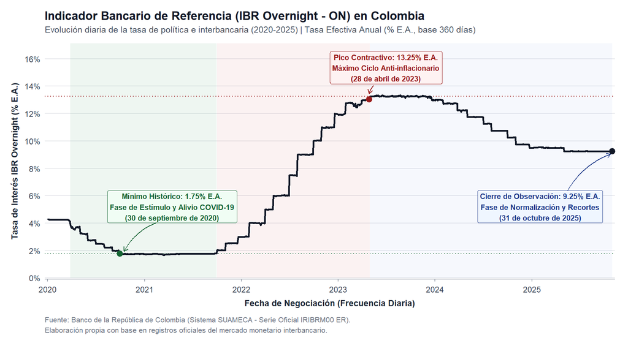

Figura 4: Evolución diaria del IBR Overnight en Colombia (2020-2025), señalando el estímulo inicial por COVID-19, el ajuste alcista y el período de normalización.

```r
color_linea_ibr <- "#111827"

pt_min_ibr   <- df_ibr |> filter(fecha == as.Date("2020-09-30"))
pt_pico_ibr  <- df_ibr |> filter(fecha == as.Date("2023-04-28"))
pt_final_ibr <- df_ibr |> filter(fecha == as.Date("2025-10-31"))

ggplot(df_ibr, aes(x = fecha, y = tasa_ibr)) +
  annotate("rect", xmin = as.Date("2020-03-27"), xmax = as.Date("2021-09-30"),
           ymin = 0, ymax = Inf, fill = "#15803d", alpha = 0.07) +
  annotate("rect", xmin = as.Date("2021-10-01"), xmax = as.Date("2023-04-30"),
           ymin = 0, ymax = Inf, fill = "#b91c1c", alpha = 0.06) +
  annotate("rect", xmin = as.Date("2023-05-01"), xmax = as.Date("2025-10-31"),
           ymin = 0, ymax = Inf, fill = "#1d4ed8", alpha = 0.04) +
  geom_hline(yintercept = 1.75, linetype = "dotted", color = "#166534", linewidth = 0.45) +
  geom_hline(yintercept = 13.25, linetype = "dotted", color = "#991b1b", linewidth = 0.45) +
  geom_line(color = color_linea_ibr, linewidth = 0.95) +
  geom_point(data = pt_min_ibr, aes(x = fecha, y = tasa_ibr), color = "#166534", size = 2.8) +
  geom_point(data = pt_pico_ibr, aes(x = fecha, y = tasa_ibr), color = "#991b1b", size = 2.8) +
  geom_point(data = pt_final_ibr, aes(x = fecha, y = tasa_ibr), color = color_linea_ibr, size = 2.8) +
  annotate("label", x = as.Date("2021-04-15"), y = 5.2,
           label = "Mínimo Histórico: 1.75% E.A.\nFase de Estímulo y Alivio COVID-19\n(30 de septiembre de 2020)",
           size = 2.85, fontface = "bold", color = "#166534", fill = "#f0fdf4",
           label.padding = unit(0.28, "lines"), linewidth = 0.3) +
  annotate("curve", x = as.Date("2021-02-15"), y = 4.05,
           xend = as.Date("2020-10-15"), yend = 1.95,
           curvature = 0.18, arrow = arrow(length = unit(1.8, "mm")),
           color = "#166534", linewidth = 0.5) +
  annotate("label", x = as.Date("2023-07-01"), y = 15.35,
           label = "Pico Contractivo: 13.25% E.A.\nMáximo Ciclo Anti-inflacionario\n(28 de abril de 2023)",
           size = 2.85, fontface = "bold", color = "#991b1b", fill = "#fef2f2",
           label.padding = unit(0.28, "lines"), linewidth = 0.3) +
  annotate("curve", x = as.Date("2023-05-15"), y = 14.05,
           xend = as.Date("2023-04-28"), yend = 13.45,
           curvature = 0.15, arrow = arrow(length = unit(1.8, "mm")),
           color = "#991b1b", linewidth = 0.5) +
  annotate("label", x = as.Date("2025-02-01"), y = 5.2,
           label = "Cierre de Observación: 9.25% E.A.\nFase de Normalización y Recortes\n(31 de octubre de 2025)",
           size = 2.85, fontface = "bold", color = "#1e3a8a", fill = "#eff6ff",
           label.padding = unit(0.28, "lines"), linewidth = 0.3) +
  annotate("curve", x = as.Date("2025-05-15"), y = 6.38,
           xend = as.Date("2025-10-25"), yend = 9.05,
           curvature = -0.18, arrow = arrow(length = unit(1.8, "mm")),
           color = "#1e3a8a", linewidth = 0.5) +
  scale_x_date(
    date_breaks = "1 year",
    date_labels = "%Y",
    limits = c(as.Date("2020-01-02"), as.Date("2025-10-31")),
    expand = expansion(mult = c(0.005, 0.005))
  ) +
  scale_y_continuous(
    labels = label_percent(scale = 1, accuracy = 1),
    breaks = seq(0, 16, by = 2),
    limits = c(0, 16.8),
    expand = expansion(mult = c(0.005, 0.02))
  ) +
  labs(
    title = "Indicador Bancario de Referencia (IBR Overnight - ON) en Colombia",
    subtitle = "Evolución diaria de la tasa de política e interbancaria (2020-2025) | Tasa Efectiva Anual (% E.A., base 360 días)",
    x = "Fecha de Negociación (Frecuencia Diaria)",
    y = "Tasa de Interés IBR Overnight (% E.A.)",
    caption = "Fuente: Banco de la República de Colombia (Sistema SUAMECA - Serie Oficial IRIBRM00 ER).\nElaboración propia con base en registros oficiales del mercado monetario interbancario."
  ) +
  tema_institucional
```

### 3.4.3 Comportamiento de la serie

#### 3.4.3.1 Estímulo monetario por COVID-19 (marzo de 2020 a septiembre de 2021)

La llegada de la pandemia en marzo de 2020 llevó a la Junta Directiva del Banco de la República a recortar su tasa de intervención en siete reuniones consecutivas, pasando de 4.25% a un mínimo histórico de 1.75% a finales de septiembre de 2020. El IBR overnight transmitió este impulso con rapidez y se mantuvo en una banda estrecha entre 1.70% y 1.75% durante doce meses, abaratando el costo del fondeo a muy corto plazo para los intermediarios financieros en una etapa de parálisis productiva.

Este piso de tasas estuvo respaldado por operaciones transitorias de liquidez (repos) en títulos públicos y privados, además de compras definitivas de títulos para evitar tensiones de liquidez en el sistema de pagos. La permanencia del IBR en 1.75% evidenció un exceso sostenido de reservas bancarias, donde los establecimientos de crédito mantuvieron saldos disponibles suficientes sin necesidad de pujar al alza por recursos interbancarios.

#### 3.4.3.2 Choque inflacionario y ciclo alcista (octubre de 2021 a abril de 2023)

Hacia el último trimestre de 2021, la reapertura comercial, los cuellos de botella en el comercio internacional y el encarecimiento de los insumos reactivaron las presiones sobre los precios al consumidor. El fenómeno se profundizó durante 2022 por el choque de materias primas derivado del conflicto en Ucrania y la depreciación del peso, lo que llevó la inflación anual por encima del 13% en los primeros meses de 2023. Ante el riesgo de desanclar las expectativas de inflación de mediano plazo, el emisor inició el ciclo contractivo más acelerado en la historia del esquema de inflación objetivo.

#### 3.4.3.3 Meseta restrictiva y normalización paulatina (mayo de 2023 a octubre de 2025)

Alcanzado el techo de 13.25% en abril de 2023, la Junta mantuvo la tasa sin cambios durante siete meses consecutivos. Esta pausa prolongada buscaba verificar que la desaceleración del índice de precios fuera consistente antes de iniciar cualquier relajamiento, dada la rigidez que mostraron los rubros de servicios y arriendos por los mecanismos formales de indexación.

En diciembre de 2023, con la inflación anual descendiendo y la inversión mostrando caídas continuas, el banco central comenzó a recortar la tasa directriz en pasos sucesivos de 50 puntos básicos. Esta fase de flexibilización situó el IBR overnight en 9.25% al cierre de octubre de 2025. Aunque el nivel actual es sustancialmente menor que el pico de 2023, la tasa real permanece en terreno neutral o moderadamente restrictivo, lo que busca afianzar la convergencia gradual de los precios hacia la meta del 3%.

## 3.5 Literal 2.B: Gráfico y análisis del SOFR Overnight (2020-2025)

### 3.5.1 Unidad de medida y convención financiera

La tasa SOFR (Secured Overnight Financing Rate) mide el costo del fondeo en dólares a 24 horas garantizado con títulos del Tesoro de Estados Unidos en el mercado repo tripartito.

- Unidad: Tasa porcentual anualizada nominal (APR, %).
- Convención de conteo: Base del mercado monetario estadounidense Actual/360 (días calendario reales sobre 360).
- Respaldo colateral: al negociarse contra deuda soberana de Estados Unidos, la tasa no incorpora primas de riesgo crediticio de contraparte bancaria, a diferencia del extinto esquema LIBOR.

### 3.5.2 Visualización histórica

**Código**

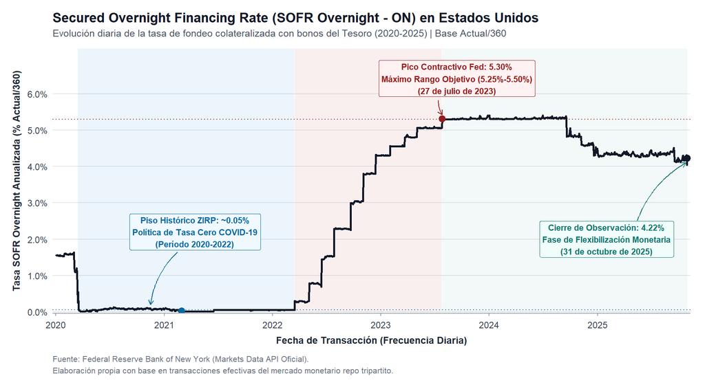

Figura 5: Evolución diaria del SOFR Overnight en Estados Unidos (2020-2025), mostrando el período de tasa cero, el ciclo de aumentos de la Reserva Federal y los recortes posteriores.

```r
color_linea_sofr <- "#111827"
color_acento_sofr <- "#0f766e"

pt_min_sofr   <- df_sofr |> filter(fecha == as.Date("2021-03-01"))
pt_pico_sofr  <- df_sofr |> filter(fecha == as.Date("2023-07-27"))
pt_final_sofr <- df_sofr |> filter(fecha == as.Date("2025-10-31"))

ggplot(df_sofr, aes(x = fecha, y = tasa_sofr)) +
  annotate("rect", xmin = as.Date("2020-03-15"), xmax = as.Date("2022-03-15"),
           ymin = 0, ymax = Inf, fill = "#0284c7", alpha = 0.08) +
  annotate("rect", xmin = as.Date("2022-03-16"), xmax = as.Date("2023-07-26"),
           ymin = 0, ymax = Inf, fill = "#b91c1c", alpha = 0.07) +
  annotate("rect", xmin = as.Date("2023-07-27"), xmax = as.Date("2025-10-31"),
           ymin = 0, ymax = Inf, fill = "#0f766e", alpha = 0.05) +
  geom_hline(yintercept = 0.05, linetype = "dotted", color = "#0369a1", linewidth = 0.45) +
  geom_hline(yintercept = 5.30, linetype = "dotted", color = "#991b1b", linewidth = 0.45) +
  geom_line(color = color_linea_sofr, linewidth = 0.95) +
  geom_point(data = pt_min_sofr, aes(x = fecha, y = tasa_sofr), color = "#0369a1", size = 2.8) +
  geom_point(data = pt_pico_sofr, aes(x = fecha, y = tasa_sofr), color = "#991b1b", size = 2.8) +
  geom_point(data = pt_final_sofr, aes(x = fecha, y = tasa_sofr), color = color_linea_sofr, size = 2.8) +
  annotate("label", x = as.Date("2021-04-15"), y = 2.2,
           label = "Piso Histórico ZIRP: ~0.05%\nPolítica de Tasa Cero COVID-19\n(Período 2020-2022)",
           size = 2.85, fontface = "bold", color = "#0369a1", fill = "#f0f9ff",
           label.padding = unit(0.28, "lines"), linewidth = 0.3) +
  annotate("curve", x = as.Date("2021-02-15"), y = 1.65,
           xend = as.Date("2020-11-15"), yend = 0.2,
           curvature = 0.18, arrow = arrow(length = unit(1.8, "mm")),
           color = "#0369a1", linewidth = 0.5) +
  annotate("label", x = as.Date("2023-09-15"), y = 6.42,
           label = "Pico Contractivo Fed: 5.30%\nMáximo Rango Objetivo (5.25%-5.50%)\n(27 de julio de 2023)",
           size = 2.85, fontface = "bold", color = "#991b1b", fill = "#fef2f2",
           label.padding = unit(0.28, "lines"), linewidth = 0.3) +
  annotate("curve", x = as.Date("2023-07-15"), y = 5.82,
           xend = as.Date("2023-07-27"), yend = 5.42,
           curvature = 0.15, arrow = arrow(length = unit(1.8, "mm")),
           color = "#991b1b", linewidth = 0.5) +
  annotate("label", x = as.Date("2025-02-01"), y = 2.0,
           label = "Cierre de Observación: 4.22%\nFase de Flexibilización Monetaria\n(31 de octubre de 2025)",
           size = 2.85, fontface = "bold", color = color_acento_sofr, fill = "#f0fdfa",
           label.padding = unit(0.28, "lines"), linewidth = 0.3) +
  annotate("curve", x = as.Date("2025-05-15"), y = 2.52,
           xend = as.Date("2025-10-25"), yend = 4.10,
           curvature = -0.18, arrow = arrow(length = unit(1.8, "mm")),
           color = color_acento_sofr, linewidth = 0.5) +
  scale_x_date(
    date_breaks = "1 year",
    date_labels = "%Y",
    limits = c(as.Date("2020-01-02"), as.Date("2025-10-31")),
    expand = expansion(mult = c(0.005, 0.005))
  ) +
  scale_y_continuous(
    labels = label_percent(scale = 1, accuracy = 0.5),
    breaks = seq(0, 6, by = 1),
    limits = c(0, 7.1),
    expand = expansion(mult = c(0.005, 0.02))
  ) +
  labs(
    title = "Secured Overnight Financing Rate (SOFR Overnight - ON) en Estados Unidos",
    subtitle = "Evolución diaria de la tasa de fondeo colateralizada con bonos del Tesoro (2020-2025) | Base Actual/360",
    x = "Fecha de Transacción (Frecuencia Diaria)",
    y = "Tasa SOFR Overnight Anualizada (% Actual/360)",
    caption = "Fuente: Federal Reserve Bank of New York (Markets Data API Oficial).\nElaboración propia con base en transacciones efectivas del mercado monetario repo tripartito."
  ) +
  tema_institucional
```

### 3.5.3 Comportamiento de la serie

#### 3.5.3.1 Política de tasa cero (ZIRP, marzo de 2020 a marzo de 2022)

Para contener el colapso financiero al inicio de la pandemia en marzo de 2020, el Comité Federal de Mercado Abierto (FOMC) redujo su tasa de referencia al rango de 0.00% a 0.25% e inició compras a gran escala de bonos del Tesoro y títulos respaldados por hipotecas. La tasa SOFR cayó rápidamente desde 1.54% a principios de 2020 hasta situarse muy cerca de cero, promediando 0.05% a lo largo de dos años continuos.

La gran cantidad de reservas inyectadas al sistema bancario generó presiones a la baja sobre las tasas a un día. Para evitar que el costo del fondeo colateralizado pasara a terreno negativo, la Reserva Federal utilizó la facilidad de operaciones de recompra inversa (Overnight Reverse Repo Facility, ON RRP), que funcionó como un piso operativo en torno a 0.05%. Este mecanismo permitió absorber el excedente de liquidez y mantener la estabilidad del mercado repo sin las tensiones observadas en septiembre de 2019.

#### 3.5.3.2 Choque inflacionario y endurecimiento acelerado (marzo de 2022 a julio de 2023)

En los primeros meses de 2022, la combinación de problemas en las cadenas globales de valor, un mercado laboral con desempleo en mínimos históricos y el estímulo fiscal pospandemia elevó la inflación anual al 9.1% en junio de 2022, el nivel más alto en cuarenta años. La Reserva Federal abandonó la premisa de transitoriedad e implementó una de las correcciones monetarias más rápidas registradas en las últimas décadas.

#### 3.5.3.3 Meseta prolongada y ciclo de recortes (agosto de 2023 a octubre de 2025)

Entre agosto de 2023 y agosto de 2024, la Reserva Federal mantuvo su tasa de intervención inalterada bajo la directriz de sostener condiciones restrictivas el tiempo necesario para doblegar la inflación. Durante este año de meseta, el SOFR osciló en una franja muy estable entre 5.30% y 5.33%, con fluctuaciones menores explicadas principalmente por efectos de calendario y fechas de liquidación del Tesoro.

En septiembre de 2024, con la inflación subyacente acercándose a la meta del 2% y señales de enfriamiento en el empleo, la Fed comenzó a flexibilizar su postura con un recorte inicial de 50 puntos básicos, seguido de reducciones adicionales de 25 puntos básicos. Hacia el 31 de octubre de 2025, el SOFR cerró en 4.22%, reflejando la transición hacia un entorno monetario menos restrictivo destinado a preservar el crecimiento sin descuidar el equilibrio de precios.

## 3.6 Literal 2.C: Gráfico con doble eje y análisis comparativo

### 3.6.1 Justificación de la frecuencia diaria

Los mercados monetarios overnight operan con vencimiento a 24 horas. El uso de datos diarios resulta indispensable para observar la volatilidad en cierres de mes, pagos tributarios y subastas de liquidez, efectos que un promedio mensual o trimestral borraría por completo.

### 3.6.2 Tratamiento de días no bursátiles cruzados

Los calendarios festivos de ambos países no coinciden: Colombia cuenta con los feriados de la Ley Emiliani y fechas religiosas, mientras que Estados Unidos observa festivos federales como el Día de Martin Luther King o el 4 de Julio.

Para integrar ambas series en una misma serie temporal sin distorsiones, se combinaron las observaciones mediante `full_join` y se imputó el valor inmediato anterior (`fill(..., .direction = "down")`). Esta regla refleja la práctica financiera habitual: cuando un mercado cierra por feriado local, los contratos vigentes continúan acumulando intereses a la última tasa oficial fijada hasta la siguiente reapertura hábil.

### 3.6.3 Visualización conjunta con doble eje

**Código**

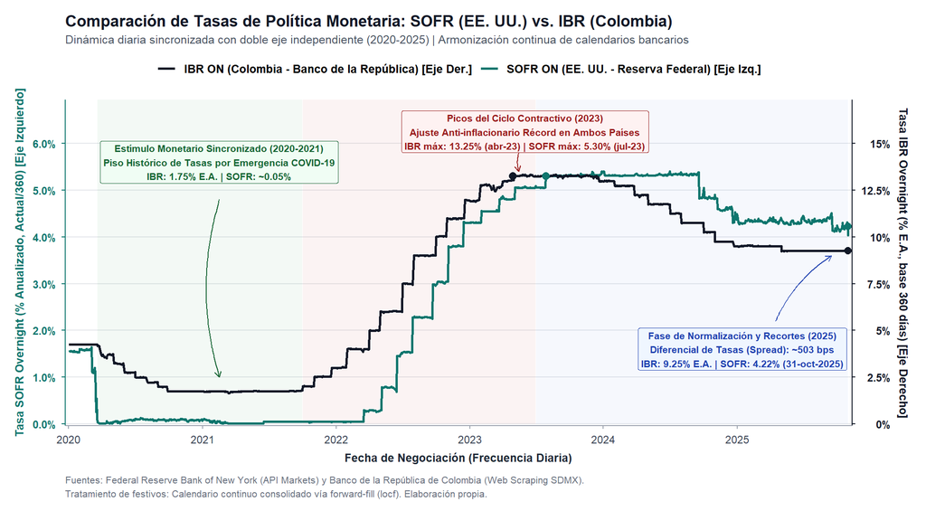

Figura 6: Comparación de tasas de referencia: SOFR en el eje izquierdo e IBR en el eje derecho (2020-2025).

```r
factor_escala <- 2.5
color_sofr_doble <- "#0f766e"
color_ibr_doble  <- "#111827"

pt_pico_ibr_c   <- tibble(fecha = as.Date("2023-04-28"), y_plot = 13.250 / factor_escala)
pt_pico_sofr_c  <- tibble(fecha = as.Date("2023-07-27"), y_plot = 5.300)
pt_final_ibr_c  <- tibble(fecha = as.Date("2025-10-31"), y_plot = 9.250 / factor_escala)
pt_final_sofr_c <- tibble(fecha = as.Date("2025-10-31"), y_plot = 4.220)

ggplot(df_consolidado, aes(x = fecha)) +
  annotate("rect", xmin = as.Date("2020-03-20"), xmax = as.Date("2021-09-30"),
           ymin = 0, ymax = Inf, fill = "#15803d", alpha = 0.05) +
  annotate("rect", xmin = as.Date("2021-10-01"), xmax = as.Date("2023-06-30"),
           ymin = 0, ymax = Inf, fill = "#b91c1c", alpha = 0.05) +
  annotate("rect", xmin = as.Date("2023-07-01"), xmax = as.Date("2025-10-31"),
           ymin = 0, ymax = Inf, fill = "#1d4ed8", alpha = 0.04) +
  geom_line(aes(y = tasa_sofr, color = "SOFR ON (EE. UU. - Reserva Federal) [Eje Izq.]"), linewidth = 0.95) +
  geom_line(aes(y = tasa_ibr / factor_escala, color = "IBR ON (Colombia - Banco de la República) [Eje Der.]"), linewidth = 0.95) +
  geom_point(data = pt_pico_sofr_c, aes(x = fecha, y = y_plot), color = color_sofr_doble, size = 2.6) +
  geom_point(data = pt_pico_ibr_c, aes(x = fecha, y = y_plot), color = color_ibr_doble, size = 2.6) +
  geom_point(data = pt_final_sofr_c, aes(x = fecha, y = y_plot), color = color_sofr_doble, size = 2.4) +
  geom_point(data = pt_final_ibr_c, aes(x = fecha, y = y_plot), color = color_ibr_doble, size = 2.4) +
  annotate("label", x = as.Date("2021-02-15"), y = 5.6,
           label = "Estímulo Monetario Sincronizado (2020-2021)\nPiso Histórico de Tasas por Emergencia COVID-19\nIBR: 1.75% E.A. | SOFR: ~0.05%",
           size = 2.8, fontface = "bold", color = "#166534", fill = "#f0fdf4",
           label.padding = unit(0.28, "lines"), linewidth = 0.3) +
  annotate("curve", x = as.Date("2021-02-15"), y = 4.8,
           xend = as.Date("2021-02-15"), yend = 1.0,
           curvature = 0.15, arrow = arrow(length = unit(1.8, "mm")),
           color = "#166534", linewidth = 0.5) +
  annotate("label", x = as.Date("2023-06-01"), y = 6.25,
           label = "Picos del Ciclo Contractivo (2023)\nAjuste Anti-inflacionario Récord en Ambos Países\nIBR máx: 13.25% (abr-23) | SOFR máx: 5.30% (jul-23)",
           size = 2.8, fontface = "bold", color = "#991b1b", fill = "#fef2f2",
           label.padding = unit(0.28, "lines"), linewidth = 0.3) +
  annotate("curve", x = as.Date("2023-05-15"), y = 5.8,
           xend = as.Date("2023-05-15"), yend = 5.4,
           curvature = 0.15, arrow = arrow(length = unit(1.8, "mm")),
           color = "#991b1b", linewidth = 0.5) +
  annotate("label", x = as.Date("2025-01-15"), y = 1.6,
           label = "Fase de Normalización y Recortes (2025)\nDiferencial de Tasas (Spread): ~503 bps\nIBR: 9.25% E.A. | SOFR: 4.22% (31-oct-2025)",
           size = 2.8, fontface = "bold", color = "#1e40af", fill = "#eff6ff",
           label.padding = unit(0.28, "lines"), linewidth = 0.3) +
  annotate("curve", x = as.Date("2025-04-15"), y = 2.2,
           xend = as.Date("2025-09-15"), yend = 3.6,
           curvature = -0.15, arrow = arrow(length = unit(1.8, "mm")),
           color = "#1e40af", linewidth = 0.5) +
  scale_color_manual(
    name = NULL,
    values = c(
      "SOFR ON (EE. UU. - Reserva Federal) [Eje Izq.]" = color_sofr_doble,
      "IBR ON (Colombia - Banco de la República) [Eje Der.]" = color_ibr_doble
    )
  ) +
  scale_x_date(
    date_breaks = "1 year",
    date_labels = "%Y",
    limits = c(as.Date("2020-01-02"), as.Date("2025-10-31")),
    expand = expansion(mult = c(0.005, 0.005))
  ) +
  scale_y_continuous(
    name = "Tasa SOFR Overnight (% Anualizado, Actual/360) [Eje Izquierdo]",
    labels = label_percent(scale = 1, accuracy = 0.5),
    limits = c(0, 6.8),
    breaks = seq(0, 6, by = 1),
    expand = expansion(mult = c(0.005, 0.02)),
    sec.axis = sec_axis(
      transform = ~ . * factor_escala,
      name = "Tasa IBR Overnight (% E.A., base 360 días) [Eje Derecho]",
      labels = label_percent(scale = 1, accuracy = 0.1, drop0trailing = TRUE),
      breaks = seq(0, 15, by = 2.5)
    )
  ) +
  labs(
    title = "Comparación de Tasas de Política Monetaria: SOFR (EE. UU.) vs. IBR (Colombia)",
    subtitle = "Dinámica diaria sincronizada con doble eje independiente (2020-2025) | Armonización continua de calendarios bancarios",
    x = "Fecha de Negociación (Frecuencia Diaria)",
    caption = "Fuentes: Federal Reserve Bank of New York (API Markets) y Banco de la República de Colombia (Web Scraping SDMX).\nTratamiento de festivos: Calendario continuo consolidado vía forward-fill (locf). Elaboración propia."
  ) +
  tema_institucional +
  theme(
    axis.title.y.left = element_text(face = "bold", size = 9.5, color = color_sofr_doble, margin = margin(r = 6)),
    axis.title.y.right = element_text(face = "bold", size = 9.5, color = color_ibr_doble, margin = margin(l = 6)),
    axis.text.y.left = element_text(color = color_sofr_doble, face = "bold"),
    axis.text.y.right = element_text(color = color_ibr_doble, face = "bold"),
    axis.line.y.left = element_line(color = color_sofr_doble, linewidth = 0.5),
    axis.line.y.right = element_line(color = color_ibr_doble, linewidth = 0.5),
    axis.ticks.y.left = element_line(color = color_sofr_doble, linewidth = 0.4),
    axis.ticks.y.right = element_line(color = color_ibr_doble, linewidth = 0.4),
    legend.position = "top",
    legend.justification = "center",
    legend.text = element_text(size = 9.5, face = "bold"),
    legend.margin = margin(b = 6)
  )
```

### 3.6.4 Interpretación económica

#### 3.6.4.1 Paridad descubierta de tasas y prima de riesgo

La diferencia en la magnitud de los ciclos (el SOFR subió 525 puntos básicos, mientras que el IBR aumentó 1,150) ilustra la dinámica de una economía emergente frente al emisor de la moneda de reserva global. Con movilidad de capitales y régimen cambiario flexible, la paridad descubierta de tasas de interés (UIP) aproximada incorpora la prima por riesgo soberano:

$$i_{t}^{COL} \approx i_{t}^{USA} + \mathbb{E}_t[\Delta s_{t+1}] + \rho_t$$

En esta expresión, $s_t$ representa el logaritmo del tipo de cambio peso/dólar y $\rho_t$ resume el riesgo país (medido comúnmente por el EMBI) y la prima por inflación. Durante 2022 y 2023, el aumento en la aversión global al riesgo y la depreciación del peso obligaron al Banco de la República a fijar un diferencial de tasas sustancialmente más alto para estabilizar las presiones cambiarias y evitar salidas desordenadas de capital.

#### 3.6.4.2 Evolución del spread financiero (IBR - SOFR)

Entre 2020 y 2021, el diferencial entre ambas tasas fluctuó entre 150 y 200 puntos básicos, un margen moderado que respondió a la abundancia de liquidez global y a la reducción sincrónica del costo del dinero por la emergencia sanitaria.

A partir de 2022, la mayor persistencia inflacionaria en Colombia y el encarecimiento de la deuda externa ampliaron este diferencial de forma considerable, superando los 800 puntos básicos durante el primer semestre de 2023 cuando el IBR alcanzó el 13.25% frente a un SOFR de 5.05%. Con el avance del proceso desinflacionario y el inicio de los recortes en ambos emisores, el spread se comprimió paulatinamente hasta ubicarse en 503 puntos básicos al 31 de octubre de 2025 (9.25% frente a 4.22%), reflejando una normalización relativa de las condiciones monetarias comparadas.

#### 3.6.4.3 Rezagos en la transmisión monetaria

Como observó Milton Friedman, las decisiones de política monetaria operan con rezagos temporales variables. El Banco de la República inició su ciclo alcista en octubre de 2021, unos seis meses antes que la Reserva Federal (marzo de 2022), lo que concuerda con la mayor sensibilidad inicial de los precios en economías en desarrollo ante choques de alimentos y materias primas. De forma similar, la persistencia de la inflación local obligó a mantener niveles restrictivos por un período más largo que el de las economías avanzadas.

# 4 Ejercicio 3: Aplicativo interactivo modular en Shiny

El tercer ejercicio del taller integra los resultados espaciales del Ejercicio 1, las series diarias de tasas interbancarias del Ejercicio 2 y los indicadores departamentales del mercado laboral en un aplicativo interactivo desarrollado en `shiny` y `bslib`. Para facilitar la lectura, el mantenimiento y la auditoría del código por parte del equipo docente, el aplicativo se estructuró de manera modular dentro del directorio [`Scripts/Punto_3/`](https://github.com/MPalma21/Talleres_de_R/tree/main/Entregable_Talleres/Taller_3/Scripts/Punto_3).

## 4.1 Arquitectura modular del aplicativo y diseño en `bslib` (Bono de Diseño)

Siguiendo las convenciones nativas de Shiny (que carga automáticamente todo archivo `.R` ubicado en la subcarpeta `R/` antes de ejecutar `app.R`), la lógica del tablero se separó en siete componentes modulares con espacios de nombres encapsulados mediante `shiny::NS()` y `shiny::moduleServer()`:

1. **`Scripts/Punto_3/01_preparar_datos_shiny.R`:** script reproducible previo al despliegue que construye y actualiza los insumos serializados en `Scripts/Punto_3/data_shiny/`, cruzando las series brutas y armonizadas de tasas (`sofr_raw`, `ibr_raw`, `falta_sofr`, `falta_ibr`, `sofr_ea`, `pi_directa`, `pi_ea` en `df_rates.rds`) y unificando los indicadores laborales de la GEIH/EMICRON 2024 con el IDF departamental 2024 en `datos_ejercicio_3c_laboral.csv` y `df_labor.rds`.
2. **`Scripts/Punto_3/R/00_tema_y_datos.R`:** centraliza la función `localizar_dir_shiny()` para resolver rutas desde cualquier directorio de trabajo, la carga defensiva de los cinco archivos `.rds` (`cargar_datos_shiny()`), la configuración del tema institucional Bootstrap 5 (`crear_tema_app()`) y el constructor de tarjetas sobrias de altura uniforme (`kpi_card_institucional()`).
3. **`Scripts/Punto_3/R/mod_tab1_idf.R`:** módulo `mod_tab1_idf_ui()` / `mod_tab1_idf_server()` para el Literal 3.A (mapa interactivo `leaflet` del IDF departamental artificial con vista agregada `"Total Nacional (Colombia)" = "NACIONAL"` y tabla académica tipo *booktabs* del Top 3 municipal).
4. **`Scripts/Punto_3/R/mod_tab2_tasas.R`:** módulo `mod_tab2_tasas_ui()` / `mod_tab2_tasas_server()` para el Literal 3.B (gráfico interactivo `plotly` de doble eje para SOFR e IBR y calculadora de devaluación implícita $\pi$ bajo convención directa y Efectiva Anual base 360).
5. **`Scripts/Punto_3/R/mod_tab3_libre.R`:** módulo `mod_tab3_libre_ui()` / `mod_tab3_libre_server()` para el Literal 3.C (explorador en `plotly` y tabla `DT` sobre dualismo laboral y capacidad fiscal departamental).
6. **`Scripts/Punto_3/www/`:** activos estáticos de interfaz institucional (`css/modern_ui.css` con variables CSS `:root`, tablas estilo *booktabs* `.table-academic`, simetría de contenedores `.card-equal-height` y *media queries* responsivas; `js/modern_ui.js` con re-renderizado dinámico de ecuaciones MathJax en `shiny:value` y redimensionamiento automático de widgets; e `img/logo_uniandes.png` recortado programáticamente).
7. **`Scripts/Punto_3/app.R`:** orquestador principal que declara explícitamente las librerías adicionales mediante comentarios `# [PAQUETE ADICIONAL]`, inyecta los activos estáticos con `withMathJax()`, construye la barra de navegación superior (`bslib::page_navbar()`) con el escudo de la Universidad de los Andes e invoca los tres servidores modulares.

```r
# Identificación explícita de paquetes adicionales en Scripts/Punto_3/app.R:
# [PAQUETE ADICIONAL]: shiny (framework de aplicaciones web interactivas y módulos NS/moduleServer)
# [PAQUETE ADICIONAL]: bslib (arquitectura de interfaz Bootstrap 5, tarjetas y paneles colapsables)
# [PAQUETE ADICIONAL]: leaflet (cartografía web interactiva para polígonos espaciales)
# [PAQUETE ADICIONAL]: plotly (gráficos interactivos con zoom, hover y doble eje)
# [PAQUETE ADICIONAL]: DT (tablas interactivas paginadas para auditoría de datos)
# [PAQUETE ADICIONAL]: sf (manejo de capas vectoriales Simple Features)
# [PAQUETE ADICIONAL]: scales (formateo de escalas numéricas y monetarias)
```

Para optar al **bono de mejor diseño**, el aplicativo implementa un sistema visual institucional inspirado en reportes de banca central y publicaciones académicas, adaptable a cualquier tamaño de pantalla: tema Bootstrap 5 personalizado (`bslib::bs_theme(version = 5, primary = "#1e3a5f", secondary = "#334155")`) con tipografías `IBM Plex Sans` e `IBM Plex Mono`, tarjetas de indicadores de fondo blanco y altura fija (`kpi_card_institucional()` de `98px` con borde izquierdo de `4px`), barras laterales retráctiles (`bslib::layout_sidebar(width = 315, open = "desktop", resizable = TRUE)`), tablas HTML tipo *booktabs* (`.table-academic`), guía rápida visible en la barra lateral de la Pestaña 2, notas técnicas en `bslib::accordion()` (colapsadas en las Pestañas 1 y 2 y abierta por defecto mediante `open = TRUE` en la Pestaña 3) y un controlador JavaScript en el cliente (`www/js/modern_ui.js`) que re-compila en tiempo real las ecuaciones dinámicas de regresión en MathJax (`MathJax.Hub.Queue(["Typeset", ...])`) y redibuja los lienzos de `Leaflet` y `Plotly` ante cambios de ventana o colapso de paneles.

## 4.2 Literal 3.A (Pestaña 1): Mapa interactivo del IDF departamental y Top 3 municipal

El primer módulo del aplicativo (`R/mod_tab1_idf.R`) integra los resultados geoespaciales del Ejercicio 1 en un tablero reactivo construido con `leaflet` y `bslib`:

1. **Insumos pre-serializados (`Scripts/Punto_3/data_shiny/`):** el script `01_procesamiento_geoespacial_idf.R` exporta automáticamente tres objetos optimizados para carga instantánea en el servidor Shiny:
   - `shp_dpto_simp.rds`: capa vectorial departamental simplificada topológicamente y transformada al sistema de coordenadas geográficas WGS84 (`EPSG:4326`), requerida por `leaflet`.
   - `df_deptos.rds`: tabla resumen de los 33 departamentos con el IDF departamental artificial, número de municipios evaluados ($n_j$), población 2024 y valor agregado proyectado 2024.
   - `df_top3.rds`: tabla con los 3 municipios de mayor calificación en el IDF municipal Vigencia 2024 dentro de cada departamento, junto con su ponderador relativo $w_i$.
2. **Interacción bidireccional entre el selector y el mapa Leaflet:**
   - Cuando el usuario hace clic sobre un polígono departamental en el mapa (`input$mapa_leaflet_shape_click`), un observador `observeEvent` actualiza automáticamente el menú desplegable (`updateSelectizeInput(session, "depto_sel", ...)`).
   - Recíprocamente, cuando el usuario elige un departamento en el menú desplegable (`input$depto_sel`), un segundo observador invoca `leafletProxy("mapa_leaflet")` para trazar un contorno resaltado sobre el departamento seleccionado y ajustar suavemente el encuadre geográfico (`flyToBounds`), manteniendo sincronizadas las tres tarjetas de indicadores (`kpi_card_institucional()`), el mapa y la tabla del Top 3 municipal.
3. **Diferenciación explícita de los dos indicadores y nota institucional:** la interfaz distingue claramente entre el **Índice Departamental (Artificial)** (media ponderada $\sum_{i=1}^{n_j} w_i \cdot \text{IDF}_i$ coloreada en el mapa) y el **Índice Municipal (Vigencia 2024)** (calificación directa del DNP mostrada en la tabla del Top 3 junto con el peso relativo $w_i$ de cada municipio). Además, para departamentos con menos de tres municipios evaluados en la medición municipal del DNP (Bogotá D. C. con 1, Archipiélago de San Andrés con 1 en Providencia, Amazonas con 2 y Guainía con 2), el tablero despliega dinámicamente una nota institucional explicando su estructura político-administrativa.

Tabla 8: Muestra de verificación de la Pestaña 1 del aplicativo Shiny: IDF departamental artificial y Top 3 municipal (con ponderadores w_i) en departamentos seleccionados (Vigencia 2024).

| Departamento | IDF Dpto. | Mpios Ev. | Pos. Top 3 | Municipio (Cód.) | IDF Mpio 2024 | Ponderador (w_i) |
| --- | --- | --- | --- | --- | --- | --- |
| Antioquia (05) | 69.58 | 125 | #1 | San Jerónimo (05656) | 76.72 | 0.0000 (0.00%) |
| Antioquia (05) | 69.58 | 125 | #2 | Copacabana (05212) | 75.34 | 0.0009 (0.09%) |
| Antioquia (05) | 69.58 | 125 | #3 | Itagüí (05360) | 75.05 | 0.0148 (1.48%) |
| Atlántico (08) | 73.03 | 23 | #1 | Barranquilla (08001) | 75.54 | 0.8586 (85.86%) |
| Atlántico (08) | 73.03 | 23 | #2 | Usiacurí (08849) | 71.60 | 0.0000 (0.00%) |
| Atlántico (08) | 73.03 | 23 | #3 | Tubará (08832) | 71.21 | 0.0001 (0.01%) |
| Bogotá, D. C. (11) | 77.04 | 1 | #1 | Bogotá, D.C. (11001) | 77.04 | 1.0000 (100.00%) |
| Boyacá (15) | 64.54 | 123 | #1 | Samacá (15646) | 81.10 | 0.0048 (0.48%) |
| Boyacá (15) | 64.54 | 123 | #2 | Sogamoso (15759) | 75.72 | 0.2328 (23.28%) |
| Boyacá (15) | 64.54 | 123 | #3 | Tuta (15837) | 73.11 | 0.0037 (0.37%) |
| Valle Del Cauca (76) | 58.29 | 42 | #1 | Yotoco (76890) | 72.13 | 0.0001 (0.01%) |
| Valle Del Cauca (76) | 58.29 | 42 | #2 | El Cerrito (76248) | 69.42 | 0.0007 (0.07%) |
| Valle Del Cauca (76) | 58.29 | 42 | #3 | Guacarí (76318) | 66.66 | 0.0002 (0.02%) |
| San Andrés, Providencia y Santa Catalina (Archipiélago) (88) | 55.23 | 1 | #1 | Providencia (88564) | 55.23 | 1.0000 (100.00%) |
| Amazonas (91) | 49.80 | 2 | #1 | Leticia (91001) | 50.20 | 0.9683 (96.83%) |
| Amazonas (91) | 49.80 | 2 | #2 | Puerto Nariño (91540) | 37.73 | 0.0317 (3.17%) |

## 4.3 Literal 3.B (Pestaña 2): Serie diaria de doble eje y calculadora de devaluación implícita ($\pi$)

El segundo módulo (`R/mod_tab2_tasas.R`) conecta la base consolidada del Ejercicio 2 con un visor interactivo de series de tiempo en `plotly` y una calculadora financiera de paridad descubierta de tasas de interés.

### 4.3.1 Especificación matemática, unidades y convención de comparabilidad

Para cada fecha $t$ seleccionada por el usuario en el control `dateInput`, el servidor transforma las tasas porcentuales anuales a su expresión en decimales ($i_d = \text{IBR}_t / 100$ para Colombia e $i_e = \text{SOFR}_t / 100$ para Estados Unidos) y evalúa la ecuación exacta de la tasa de devaluación implícita anualizada ($\pi_t$):

$$\pi_t = \frac{1 + i_{d,t}}{1 + i_{e,t}} - 1$$

El resultado $\pi_t$ se reporta tanto en **porcentaje efectivo anualizado (% anual)** como en **decimales**, acompañado del diferencial simple en puntos básicos ($\text{Spread}_t = (i_{d,t} - i_{e,t}) \times 10,000$). Adicionalmente, dado que el Banco de la República publica el IBR Overnight como tasa Efectiva Anual (`% E.A.`, base 360) mientras que la Reserva Federal de Nueva York publica la SOFR como tasa nominal anualizada (*Simple Interest*, `Actual/360`), la calculadora ofrece un selector (`radioButtons`) con dos convenciones transparentes:

1. **Convención directa sobre tasas publicadas en decimales:** utiliza $i_d = \text{IBR}_{\text{EA}}/100$ e $i_e = \text{SOFR}_{\text{nom}}/100$ directamente de las fuentes oficiales.
2. **Convención homogeneizada en Efectiva Anual (`% E.A.`, base 360):** capitaliza primero la tasa diaria de Estados Unidos a Efectiva Anual mediante $i_{e,\text{EA}} = \left(1 + \frac{i_{e,\text{nom}}}{360}\right)^{360} - 1$ antes de evaluar $\pi_t^{\text{EA}} = \frac{1 + i_{d,\text{EA}}}{1 + i_{e,\text{EA}}} - 1$.

Al conmutar entre ambas convenciones, el módulo actualiza de manera simultánea las tarjetas de indicadores (`kpi_card_institucional()`), la serie SOFR (`sofr_on` vs. `sofr_ea`), sus hitos y el título del eje izquierdo en el gráfico interactivo Plotly, complementado con instrucciones breves de uso directamente en la barra lateral.

### 4.3.2 Detección explícita de fechas sin cotización primaria (fines de semana y festivos asimétricos)

Para cumplir rigurosamente la instrucción del Literal 3.B de informar al usuario si falta alguna de las tasas en la fecha elegida, el objeto `df_rates.rds` conserva tanto las series crudas (`sofr_raw`, `ibr_raw`) como los indicadores lógicos `falta_sofr` y `falta_ibr` y las series con arrastre del último día hábil (`sofr_on`, `ibr_on`). De este modo, el banner reactivo `banner_alerta_fecha` distingue cuatro estados:

- **Cotización primaria verificada:** ambos bancos centrales publicaron tasa oficial en la fecha seleccionada.
- **Festivo bancario en Colombia (`falta_ibr == TRUE`):** día hábil en Estados Unidos pero feriado nacional en Colombia (74 días en la muestra, p. ej., `2025-08-07`, Batalla de Boyacá). El aplicativo informa que falta la observación primaria de IBR y muestra el cálculo empleando la última tasa oficial vigente (*forward-fill*).
- **Feriado federal en Estados Unidos (`falta_sofr == TRUE`):** día hábil en Colombia pero festivo en el mercado del Tesoro estadounidense (42 días en la muestra, p. ej., `2024-07-04`, Día de la Independencia de EE. UU.). El aplicativo avisa que falta la observación primaria de SOFR y emplea el último registro hábil.
- **Fin de semana o feriado simultáneo (`nrow(reg) == 0`):** ningún mercado operó en esa fecha (p. ej., sábado `2024-10-12`); el tablero despliega una alerta amarilla e indica cuál fue el último día hábil previo disponible.

La Tabla 9 documenta la verificación numérica de la calculadora de la Pestaña 2 en seis fechas de control representativas:

Tabla 9: Verificación de la calculadora de devaluación implícita ($\pi$) en la Pestaña 2 bajo ambas convenciones y diagnóstico de disponibilidad primaria.

| Fecha | Estado de Cotización | IBR ON (% E.A.) | SOFR Pub. (%) | SOFR (% E.A.) | Deval. Directa (% anual) | Deval. Homog. E.A. (% anual) |
| --- | --- | --- | --- | --- | --- | --- |
| 2020-01-02 | Primaria en ambos mercados | 4.259% | 1.54% | 1.552% | 2.678% | 2.666% |
| 2023-04-28 | Primaria en ambos mercados | 13.027% | 4.81% | 4.927% | 7.840% | 7.719% |
| 2024-03-15 | Primaria en ambos mercados | 12.747% | 5.31% | 5.453% | 7.062% | 6.917% |
| 2024-07-04 | Festivo EE. UU. (Forward-fill SOFR) | 11.255% | 5.33% | 5.474% | 5.625% | 5.481% |
| 2025-08-07 | Festivo Col (Forward-fill IBR) | 9.250% | 4.35% | 4.446% | 4.696% | 4.600% |
| 2025-10-31 | Primaria en ambos mercados | 9.250% | 4.22% | 4.310% | 4.826% | 4.736% |

## 4.4 Literal 3.C (Pestaña 3): Diseño libre en Plotly sobre dualismo laboral y desempeño fiscal

Para la tercera pestaña del aplicativo (`R/mod_tab3_libre.R`), el Grupo 10 diseñó una visualización interactiva en `plotly` que articula los indicadores departamentales del mercado laboral construidos por el equipo en los talleres previos a partir de los microdatos de la **GEIH y EMICRON 2024 (DANE)** con el **Índice de Desempeño Fiscal (IDF) Departamental Artificial 2024 (DNP)** estimado en el Ejercicio 1. La base integrada se exporta de forma reproducible en `Scripts/Punto_3/datos_ejercicio_3c_laboral.csv` y `Scripts/Punto_3/data_shiny/df_labor.rds` para los 24 dominios departamentales representativos de la GEIH.

### 4.4.1 Diseño visual y controles interactivos

El gráfico de burbujas en `plotly` codifica cuatro dimensiones económicas simultáneas, incorpora una explicación técnica visible por defecto al pie de la pestaña (`bslib::accordion(..., open = TRUE)`) y ofrece cinco controles interactivos en la barra lateral:

1. **Eje horizontal ($X$):** Tasa de Informalidad Laboral departamental (%, definición DANE).
2. **Eje vertical seleccionable ($Y$):** mediante un `selectInput`, el usuario puede alternar entre la **Mediana del Ingreso Laboral Mensual (COP)** y el **IDF Departamental Artificial 2024 (puntos)**.
3. **Tamaño y color de las burbujas:** el área de cada marcador es proporcional al volumen de **ocupados expandidos** del departamento y el color identifica las **seis regiones geográficas** (`Central`, `Caribe`, `Pacífica`, `Oriental`, `Bogotá D.C.` y `Amazonía/Orinoquía`), filtrables mediante un `checkboxGroupInput`, un botón de restablecimiento rápido y un `sliderInput` de tamaño mínimo del mercado laboral.
4. **Capas analíticas activables (`checkboxInput`):** dos casillas de verificación permiten superponer en tiempo real la recta de ajuste por Mínimos Cuadrados Ordinarios (MCO) y las líneas punteadas que dividen el plano en cuatro cuadrantes según el promedio nacional de informalidad y de la variable elegida en el eje vertical.
5. **Tarjetas reactivas (`kpi_card_institucional()`) y pestaña de auditoría (`DT`):** la parte superior recalcula dinámicamente la informalidad media (simple y ponderada por ocupados), el promedio de la variable vertical seleccionada y el coeficiente de correlación lineal de Pearson ($r$) para el subconjunto filtrado, mientras que la pestaña secundaria en `navset_card_underline()` permite inspeccionar, ordenar y buscar los registros exactos en una tabla interactiva `DT`.

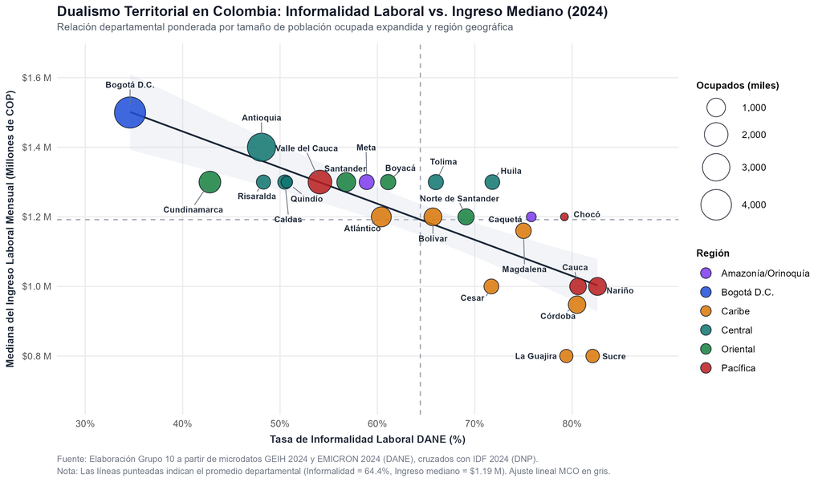

Figura 7: Dualismo laboral y capacidad fiscal departamental en Colombia (2024): relación entre informalidad laboral (GEIH/EMICRON) e ingreso laboral mediano mensual, ponderada por ocupados expandidos.

### 4.4.2 Explicación económica de los datos y hallazgos

La Tabla 10 sintetiza el comportamiento agregado por región geográfica a partir de la base integrada del Literal 3.C:

Tabla 10: Síntesis regional de informalidad laboral, ingreso laboral mediano e Índice de Desempeño Fiscal (IDF) departamental artificial (2024).

| Región Geográfica | Dptos. | Ocupados Exp. (miles) | Informalidad Pond. (%) | Ingreso Mediano Prom. (COP) | IDF Dpto. Prom. (pts) |
| --- | --- | --- | --- | --- | --- |
| Bogotá D.C. | 1 | 4,228.9 | 34.6% | $1,500,000 | 77.04 |
| Central | 6 | 5,422.6 | 52.4% | $1,316,667 | 59.31 |
| Oriental | 4 | 3,874.0 | 53.8% | $1,275,000 | 61.40 |
| Amazonía/Orinoquía | 2 | 687.9 | 62.9% | $1,250,000 | 51.30 |
| Pacífica | 4 | 3,807.4 | 66.9% | $1,125,000 | 58.96 |
| Caribe | 7 | 4,806.1 | 71.0% | $1,015,357 | 60.77 |

El cruce empírico entre los indicadores laborales y fiscales de 2024 pone de relieve dos mecanismos estructurales del desarrollo regional colombiano:

1. **Penalización salarial de la informalidad ($r = -0.81$):** existe una fuerte asociación negativa entre la tasa de informalidad departamental y la mediana del ingreso laboral mensual. Mientras que **Bogotá D. C.** ($34.6\%$ de informalidad, $\$1,500,000$ COP de ingreso mediano) y **Antioquia** ($48.1\%$ de informalidad, $\$1,400,000$ COP) se ubican en el cuadrante superior izquierdo de alta formalidad y mayor remuneración, departamentos periféricos como **Nariño** ($82.6\%$, $\$1,000,000$ COP), **Sucre** ($82.1\%$, $\$800,000$ COP), **Cauca** ($80.6\%$, $\$1,000,000$ COP), **Córdoba** ($80.5\%$, $\$947,500$ COP) y **La Guajira** ($79.4\%$, $\$800,000$ COP) concentran alrededor de cuatro de cada cinco ocupados en unidades informales de baja productividad con ingresos mensuales iguales o inferiores a un millón de pesos.
2. **Vínculo entre tejido empresarial formal y capacidad fiscal local ($r = -0.52$):** al conmutar el eje vertical hacia el IDF Departamental Artificial 2024, se confirma que los departamentos con menor informalidad laboral exhiben también una mayor solidez en sus finanzas públicas territoriales. La formalidad empresarial y laboral amplía la base gravable del Impuesto de Industria y Comercio (ICA) y fortalece la cultura tributaria del impuesto predial en las capitales y nodos industriales (Bogotá D. C. con $77.04$ puntos, Atlántico con $73.03$ y Antioquia con $69.58$), mientras que las economías departamentales con alta informalidad enfrentan severas restricciones de recaudo propio y mayor dependencia de las transferencias nacionales (La Guajira con $46.87$ puntos y Caquetá con $42.11$ puntos).

# 5 Matriz consolidada de verificación antes de entregar

En cumplimiento de la sección *“Verificación antes de entregar”* del enunciado del Taller 3, la Tabla 11 consolida las cuatro evidencias de auditoría y doble comprobación ejecutadas sobre los datos y cálculos del proyecto:

Tabla 11: Matriz de verificación integral del Taller 3 (Grupo 10).

[output not shown]

# 6 Conclusiones

1. **Integración geoespacial y homogeneidad del ponderador fiscal (Ejercicio 1):** la estandarización programática de las llaves DIVIPOLA de cinco dígitos (`cod_mpio`) permitió cruzar sin alteraciones manuales las cuentas de Valor Agregado 2023 y Proyecciones de Población 2024 del DANE (1,123 territorios) con el Índice de Desempeño Fiscal Municipal Vigencia 2024 del DNP (1,103 municipios evaluados), identificando con exactitud las 18 Áreas No Municipalizadas, Mapiripana y San Andrés Isla (y la ausencia de polígono propio para Nuevo Belén de Bajirá `27493` en la malla MGN 2018 de 1,122 polígonos). Se demostró analítica y computacionalmente que el ponderador demográfico-económico $w_i$ es homogéneo de grado cero frente a la tasa de proyección del PIB ($g = 8.27\%$ nominal en 2024), con cierre exacto $\sum_{i=1}^{n_j} w_i = 1$ en los 33 departamentos y discrepancia nula frente al cálculo alternativo. Asimismo, la simplificación topológica de Visvalingam-Whyatt (`rmapshaper::ms_simplify`, Bono 1) optimizó el renderizado de los 1,122 polígonos municipales sin fracturar fronteras colindantes.
2. **Captura programática diferenciada y armonización de calendarios financieros (Ejercicio 2):** la extracción automatizada mediante API REST JSON para la tasa SOFR (Fed de Nueva York) y web scraping sobre documentos SDMX-XML para el IBR Overnight (Banco de la República) garantizó la trazabilidad primaria de las 1,500 observaciones hábiles entre enero de 2020 y octubre de 2025. La consolidación en calendario continuo con arrastre del último valor hábil (*forward-fill*) corrigió las asimetrías de 74 festivos bancarios colombianos y 42 feriados estadounidenses, permitiendo cuantificar la ampliación del diferencial de tasas durante el ciclo inflacionario pospandemia (superando los 800 puntos básicos en 2023) y su posterior convergencia hacia 503 puntos básicos al cierre de octubre de 2025.
3. **Arquitectura modular en Shiny, paridad cambiaria y dualismo territorial (Ejercicio 3):** la estructuración del tablero interactivo en módulos independientes (`R/00_tema_y_datos.R`, `R/mod_tab1_idf.R`, `R/mod_tab2_tasas.R` y `R/mod_tab3_libre.R`) bajo `bslib` (Bootstrap 5) permitió articular en una sola herramienta auditable la exploración cartográfica del IDF (Pestaña 1), la simulación diaria de la devaluación implícita $\pi_t = (1 + i_d)/(1 + i_e) - 1$ con detección explícita de festivos y selector de convención efectiva anual (Pestaña 2), y el análisis multidimensional en `plotly` del vínculo entre informalidad laboral, ingresos medianos y desempeño fiscal departamental (Pestaña 3).

# 7 Anexo: Declaración de uso de Inteligencia Artificial Generativa (Nivel 3 Uniandes)

En cumplimiento de la directriz expresa del enunciado del Taller 3 y de los *Lineamientos para el uso de Inteligencia Artificial Generativa (IAG) en la Universidad de los Andes* (octubre de 2024, **Nivel 3: Edición, refinamiento y soporte técnico auxiliar**), el **Grupo 10** declara de manera transparente el protocolo de asistencia tecnológica empleado durante el desarrollo del proyecto:

1. **Herramienta, funciones institucionales y enlaces públicos verificados:** se utilizó **Google Gemini** exclusivamente en funciones de asistencia en programación (Función 4) y refinamiento de maquetación visual (Función 1). Las dos sesiones completas de trabajo se encuentran disponibles públicamente para verificación del equipo docente y consolidadas en el documento Word adjunto `uso de IA/Anexo_Uso_IA_Taller_3_Grupo_10.docx`:
   - **Sesión 1 (Soporte técnico de sintaxis en los 3 ejes temáticos):** https://share.gemini.google/sRSea3dbMXqg — consultas puntuales sobre `rmapshaper::ms_simplify(keep_shapes = TRUE)`, expresiones XPath independientes de prefijos con `local-name()` en `xml2`, propagación `tidyr::fill()` con banderas de festivos, homogeneización a Efectiva Anual base 360 y reactividad con `leafletProxy()`.
   - **Sesión 2 (Refinamiento del frontend UI del aplicativo Shiny):** https://share.gemini.google/NmaotI84oYiV — consultas sobre maquetación institucional en `bslib`, tarjetas `kpi_card_institucional()`, tablas CSS tipo *booktabs* (`www/css/modern_ui.css`), recorte programático del escudo institucional (`png::readPNG`/`writePNG`) y controlador JavaScript en cliente (`www/js/modern_ui.js`) para re-renderizar ecuaciones dinámicas en MathJax.
2. **Autoría intelectual humana y validación empírica:** la totalidad de las interpretaciones económicas (primacía urbana en el IDF departamental, transmisión monetaria comparada bajo paridad descubierta de tasas de interés y dualismo laboral centro-periferia), así como la verificación cruzada de cada cifra frente a las fuentes primarias del DANE, DNP, Banco de la República y Reserva Federal de Nueva York, fueron realizadas y redactadas directamente por los tres integrantes del Grupo 10.
3. **Registro de auditoría y descarte de alucinaciones:** durante las sesiones se identificaron, auditaron y descartaron propuestas iniciales que presentaban inconsistencias técnicas o metodológicas:
   - *Simplificación geométrica aislada (`sf::st_simplify`):* generaba grietas (*slivers*) entre municipios vecinos; se reemplazó por el algoritmo topológico de Visvalingam-Whyatt (`rmapshaper::ms_simplify(keep = 0.08, keep_shapes = TRUE)`), preservando los 1,122 polígonos municipales.
   - *Cruce temporal con `inner_join` en series con festivos asimétricos:* eliminaba 116 días hábiles donde operó solo uno de los dos mercados (74 festivos en Colombia y 42 en EE. UU.); se sustituyó por un calendario continuo de días hábiles (`N = 1,500`) con imputación explícita por *forward-fill* (`tidyr::fill(.direction = "down")`) y banderas de auditoría (`falta_ibr`, `falta_sofr`).
   - *Truncamiento de fórmulas LaTeX y ecuaciones dinámicas en Shiny:* se corrigió el escape del símbolo `\%` dentro de delimitadores `\(...\)` y se implementó el escuchador del evento `shiny:value` en `www/js/modern_ui.js` para re-invocar `MathJax.Hub.Queue(["Typeset", ...])` al actualizar la ecuación MCO en la Pestaña 3.

El documento anexo completo en formato Word se encuentra en `Entregable_Talleres/Taller_3/uso de IA/Anexo_Uso_IA_Taller_3_Grupo_10.docx` y el resumen general del repositorio en [`evidencias_IA/README.md`](https://github.com/MPalma21/Talleres_de_R/blob/main/evidencias_IA/README.md).